# Análisis Univariado y Multivariado: Estadísticas de Jugadores de la NBA

Temporadas 1982-2022 — Dataset depurado (`nbaFINAL.csv`): 10 variables clave, análisis univariado completo y matriz de correlación sobre datos estandarizados

Análisis exploratorio de datos (EDA)

18 de septiembre de 2026

# 1 Introducción

Este documento presenta un **análisis exploratorio univariado y multivariado** del dataset **`nbaFINAL.csv`**, la versión **depurada** del dataset de estadísticas de jugadores de la NBA publicado originalmente por Basketball-Reference. Contiene **14,078 registros temporada-jugador** entre las temporadas 1982 y 2022 (41 temporadas) y **54 variables**, que combinan estadísticas tradicionales de caja (puntos, rebotes, asistencias, tiros de campo) con métricas avanzadas por posesión (PER, Win Shares, Box Plus/Minus, VORP, porcentaje de uso).

Frente al archivo original, esta versión incorpora tres decisiones de limpieza que condicionan todo el análisis posterior y que conviene tener presentes desde el inicio:

1. **Filtro de `minutos_totales >= 100`.** Se eliminaron los jugadores con participación marginal en la temporada. Este es el cambio más importante desde el punto de vista estadístico: las métricas de **tasa** (PER, Box Plus/Minus, Win Shares por 48 minutos) son cocientes y tomaban valores absurdos —PER superiores a 100 o inferiores a −90— en jugadores con uno o dos minutos jugados en todo el año. Con el filtro, el PER queda acotado a un rango plausible (-4.8 a 32.8) y los boxplots dejan de estar dominados por ruido de muestras diminutas.
2. **Eliminación de las filas `"TOT"`.** Las filas-resumen de jugadores transferidos a mitad de temporada (que no corresponden a ninguna franquicia real y duplicaban minutos ya contabilizados) fueron retiradas: el dataset tiene **0 filas `"TOT"`**, por lo que los análisis agregados por equipo ya no requieren un tratamiento especial.
3. **Consolidación de `posicion` en 5 categorías.** Las combinaciones híbridas poco frecuentes (“SG-PF”, “SG-PG-SF”, etc.) se resolvieron a la posición principal, dejando **5 categorías limpias** (C, PF, SF, SG, PG) con tamaños de muestra comparables entre sí.

El objetivo no es solo describir matemáticamente cada variable (media, mediana, desviación estándar, asimetría), sino **interpretar qué significa cada resultado desde una perspectiva de analítica deportiva**: qué le diría este dato a un analista de rendimiento, a un cuerpo técnico o a un front office que evalúa jugadores.

# 2 Descripción del dataset

Cada fila del dataset representa el desempeño de **un jugador en una temporada**. Cuando un jugador fue transferido a mitad de temporada, aparece con una fila por cada franquicia en la que jugó (ya no existe la fila-resumen `"TOT"`). El conjunto contiene **14,078 registros y 54 variables**:

- **Identificación:** nombre del jugador (`jugador`), 2,695 jugadores distintos.
- **Variables categóricas:** posición de juego (`posicion`, 5 categorías) y equipo/franquicia (`equipo`, 40 códigos).
- **Variables numéricas discretas/temporales:** `temporada`, `edad`, `partidos_jugados`, `partidos_titular` y `minutos_totales`.
- **Variables numéricas continuas:** estadísticas “por partido” (tiros, rebotes, asistencias, puntos), porcentajes de tiro, métricas avanzadas normalizadas por posesión (`porc_*`) e indicadores compuestos de valor del jugador (PER, Win Shares, BPM, VORP) y del equipo (margen de victoria, porcentaje de victorias).

El objetivo del análisis es describir el comportamiento individual de las variables y extraer información útil desde una perspectiva de analítica deportiva, en particular sobre la relación entre el **uso** de un jugador (minutos, tiros, USG%), su **producción** estadística y las métricas **compuestas de valor**.

# 3 Lectura y transformación de las variables

El archivo CSV se importa con `read_csv()` (paquete `readr`). Las variables de texto (`jugador`, `posicion`, `equipo`) se convierten a `factor` mediante:

```r
df <- df %>%
  mutate(across(where(is.character), as.factor))
```

`jugador` queda técnicamente como factor, pero **no se trata como variable categórica de análisis**: tiene 2,695 valores distintos, por lo que cumple el rol de **identificador/etiqueta**, no de categoría analizable con tablas de frecuencia. `posicion` y `equipo`, en cambio, sí son variables categóricas propiamente dichas (pocas categorías, cada una con un significado sustantivo) y se analizan como tales más adelante.

# 4 Diccionario de datos

Antes de analizar es indispensable entender **qué mide cada variable, en qué escala está y cómo se calcula**, porque en este dataset varias columnas empiezan con `porc_` (“porcentaje”) pero **no todas están en la misma escala**: algunas son fracciones entre 0.0 y 1.0 (por ejemplo `porc_tiro_campo`), mientras que otras son puntos porcentuales entre 0 y 100 (por ejemplo `porc_uso_jugador`). Ignorar esta diferencia es una fuente común de errores de interpretación — y es también la razón por la que la matriz de correlación de la última sección se calcula **sobre las variables estandarizadas**.

```r
diccionario <- tribble(
  ~Variable, ~Tipo, ~Descripcion_academica, ~Como_se_mide,
  "temporada", "Numérica discreta (temporal)", "Temporada de la NBA (el año indica el año de cierre de la temporada; 1982 = temporada 1981-82).", "Año (1982 a 2022).",
  "jugador", "Identificador", "Nombre del jugador.", "Texto libre, 2,695 jugadores distintos; no se analiza univariadamente.",
  "posicion", "Categórica", "Posición principal jugada en la temporada.", "Texto, 5 categorías limpias (C, PF, SF, SG, PG).",
  "edad", "Numérica discreta", "Edad del jugador durante esa temporada.", "Años (18 a 43).",
  "equipo", "Categórica", "Equipo/franquicia para el que jugó esa temporada.", "Texto, 40 códigos reales (sin \"TOT\"; incluye franquicias reubicadas/renombradas).",
  "partidos_jugados", "Numérica discreta", "Partidos jugados en la temporada.", "Conteo entero (3 a 82).",
  "partidos_titular", "Numérica discreta", "Partidos jugados como titular.", "Conteo entero (0 a 82, siempre ≤ partidos_jugados).",
  "minutos_pp", "Numérica continua", "Minutos jugados por partido.", "Minutos (3.0 a 43.7).",
  "tiros_anotados_pp", "Numérica continua", "Canastas de campo anotadas por partido.", "Conteo por partido.",
  "tiros_intentados_pp", "Numérica continua", "Intentos de canasta de campo por partido.", "Conteo por partido.",
  "porc_tiro_campo", "Numérica continua", "Porcentaje de acierto en tiros de campo.", "Fracción 0.0-1.0.",
  "triples_anotados_pp", "Numérica continua", "Triples anotados por partido.", "Conteo por partido.",
  "triples_intentados_pp", "Numérica continua", "Intentos de triple por partido.", "Conteo por partido.",
  "porc_triple", "Numérica continua", "Porcentaje de acierto en triples.", "Fracción 0.0-1.0 (NA si 0 intentos).",
  "dobles_anotados_pp", "Numérica continua", "Tiros de 2 puntos anotados por partido.", "Conteo por partido.",
  "dobles_intentados_pp", "Numérica continua", "Intentos de tiro de 2 puntos por partido.", "Conteo por partido.",
  "porc_doble", "Numérica continua", "Porcentaje de acierto en tiros de 2 puntos.", "Fracción 0.0-1.0 (NA si 0 intentos).",
  "porc_tiro_efectivo", "Numérica continua", "Porcentaje de tiro efectivo (pondera el mayor valor del triple).", "Fracción 0.0-1.0.",
  "libres_anotados_pp", "Numérica continua", "Tiros libres anotados por partido.", "Conteo por partido.",
  "libres_intentados_pp", "Numérica continua", "Intentos de tiro libre por partido.", "Conteo por partido.",
  "porc_libre", "Numérica continua", "Porcentaje de acierto en tiros libres.", "Fracción 0.0-1.0 (NA si 0 intentos).",
  "rebotes_of_pp", "Numérica continua", "Rebotes ofensivos por partido.", "Conteo por partido.",
  "rebotes_def_pp", "Numérica continua", "Rebotes defensivos por partido.", "Conteo por partido.",
  "rebotes_totales_pp", "Numérica continua", "Rebotes totales por partido (= rebotes_of_pp + rebotes_def_pp).", "Conteo por partido.",
  "asistencias_pp", "Numérica continua", "Asistencias por partido.", "Conteo por partido.",
  "robos_pp", "Numérica continua", "Robos de balón por partido.", "Conteo por partido.",
  "tapones_pp", "Numérica continua", "Bloqueos por partido.", "Conteo por partido.",
  "perdidas_pp", "Numérica continua", "Pérdidas de balón por partido.", "Conteo por partido.",
  "faltas_pp", "Numérica continua", "Faltas personales por partido.", "Conteo por partido.",
  "puntos_pp", "Numérica continua", "Puntos anotados por partido.", "Conteo por partido.",
  "minutos_totales", "Numérica discreta", "Minutos totales jugados en la temporada.", "Conteo entero (100 a 3,533 por el filtro de depuración).",
  "indice_eficiencia", "Numérica continua", "Player Efficiency Rating: índice compuesto de eficiencia por minuto, ajustado por ritmo (15.0 = promedio de liga).", "Escala centrada en 15 (puede ser negativa).",
  "porc_tiro_verdadero", "Numérica continua", "Porcentaje de tiro verdadero (pondera tiros de 2, 3 y libres en una sola medida de eficiencia anotadora).", "Fracción 0.0-1.0.",
  "porc_intentos_triple", "Numérica continua", "Proporción de los intentos de campo que fueron de triple.", "Fracción 0.0-1.0.",
  "razon_libres_intentos", "Numérica continua", "Razón entre intentos de tiro libre e intentos de campo.", "Razón no acotada a [0,1] (0 a 1.5 en este dataset).",
  "porc_rebotes_of_disp", "Numérica continua", "% estimado de rebotes ofensivos disponibles capturados mientras el jugador estuvo en cancha.", "Puntos porcentuales 0-100.",
  "porc_rebotes_def_disp", "Numérica continua", "% estimado de rebotes defensivos disponibles capturados.", "Puntos porcentuales 0-100.",
  "porc_rebotes_tot_disp", "Numérica continua", "% estimado de rebotes totales disponibles capturados.", "Puntos porcentuales 0-100.",
  "porc_asistencias_equipo", "Numérica continua", "% estimado de canastas de compañeros asistidas mientras el jugador estuvo en cancha.", "Puntos porcentuales 0-100.",
  "porc_robos_equipo", "Numérica continua", "% estimado de posesiones rivales que terminaron en robo del jugador.", "Puntos porcentuales 0-25.",
  "porc_tapones_equipo", "Numérica continua", "% estimado de tiros de campo rivales de 2 puntos bloqueados por el jugador.", "Puntos porcentuales 0-100.",
  "porc_perdidas_jugada", "Numérica continua", "Pérdidas de balón estimadas por cada 100 jugadas individuales.", "Puntos porcentuales 0-100.",
  "porc_uso_jugador", "Numérica continua", "% estimado de las jugadas del equipo \"usadas\" por el jugador mientras estuvo en cancha.", "Puntos porcentuales 0-100.",
  "victorias_ofensiva", "Numérica continua", "Win Shares ofensivos: victorias atribuidas a la contribución ofensiva del jugador.", "Puede ser negativo.",
  "victorias_defensa", "Numérica continua", "Win Shares defensivos.", "Puede ser negativo.",
  "victorias_total", "Numérica continua", "Win Shares totales (= victorias_ofensiva + victorias_defensa).", "Puede ser negativo.",
  "victorias_por_48min", "Numérica continua", "Win Shares por cada 48 minutos (ritmo de un partido completo).", "Puede ser negativo.",
  "masmenos_ofensivo", "Numérica continua", "Box Plus/Minus ofensivo (puntos por 100 posesiones sobre el jugador promedio de liga).", "Puede ser negativo.",
  "masmenos_defensivo", "Numérica continua", "Box Plus/Minus defensivo (impacto defensivo en puntos por 100 posesiones).", "Puede ser negativo.",
  "masmenos_total", "Numérica continua", "Box Plus/Minus total (= masmenos_ofensivo + masmenos_defensivo).", "Puede ser negativo.",
  "valor_sobre_reemplazo", "Numérica continua", "Value Over Replacement Player: valor acumulado del jugador respecto a un jugador de reemplazo de nivel mínimo.", "Puede ser negativo.",
  "margen_victoria", "Numérica continua", "Margen de victoria promedio del equipo del jugador esa temporada (diferencia de puntos por partido).", "Puede ser negativo.",
  "margen_victoria_ajust", "Numérica continua", "Margen de victoria del equipo, ajustado por fuerza de calendario.", "Puede ser negativo.",
  "porc_victorias_equipo", "Numérica continua", "Porcentaje de victorias del equipo del jugador esa temporada.", "Fracción 0.0-1.0."
)

diccionario %>%
  kable(
    col.names = c("Variable", "Tipo", "Qué representa", "Cómo se mide / escala")
  ) %>%
  kable_styling(
    bootstrap_options = c("striped", "hover", "condensed"),
    font_size = 11
  ) %>%
  column_spec(1, bold = TRUE, width = "13%")
```

| Variable | Tipo | Qué representa | Cómo se mide / escala |
| --- | --- | --- | --- |
| temporada | Numérica discreta (temporal) | Temporada de la NBA (el año indica el año de cierre de la temporada; 1982 = temporada 1981-82). | Año (1982 a 2022). |
| jugador | Identificador | Nombre del jugador. | Texto libre, 2,695 jugadores distintos; no se analiza univariadamente. |
| posicion | Categórica | Posición principal jugada en la temporada. | Texto, 5 categorías limpias (C, PF, SF, SG, PG). |
| edad | Numérica discreta | Edad del jugador durante esa temporada. | Años (18 a 43). |
| equipo | Categórica | Equipo/franquicia para el que jugó esa temporada. | Texto, 40 códigos reales (sin “TOT”; incluye franquicias reubicadas/renombradas). |
| partidos_jugados | Numérica discreta | Partidos jugados en la temporada. | Conteo entero (3 a 82). |
| partidos_titular | Numérica discreta | Partidos jugados como titular. | Conteo entero (0 a 82, siempre ≤ partidos_jugados). |
| minutos_pp | Numérica continua | Minutos jugados por partido. | Minutos (3.0 a 43.7). |
| tiros_anotados_pp | Numérica continua | Canastas de campo anotadas por partido. | Conteo por partido. |
| tiros_intentados_pp | Numérica continua | Intentos de canasta de campo por partido. | Conteo por partido. |
| porc_tiro_campo | Numérica continua | Porcentaje de acierto en tiros de campo. | Fracción 0.0-1.0. |
| triples_anotados_pp | Numérica continua | Triples anotados por partido. | Conteo por partido. |
| triples_intentados_pp | Numérica continua | Intentos de triple por partido. | Conteo por partido. |
| porc_triple | Numérica continua | Porcentaje de acierto en triples. | Fracción 0.0-1.0 (NA si 0 intentos). |
| dobles_anotados_pp | Numérica continua | Tiros de 2 puntos anotados por partido. | Conteo por partido. |
| dobles_intentados_pp | Numérica continua | Intentos de tiro de 2 puntos por partido. | Conteo por partido. |
| porc_doble | Numérica continua | Porcentaje de acierto en tiros de 2 puntos. | Fracción 0.0-1.0 (NA si 0 intentos). |
| porc_tiro_efectivo | Numérica continua | Porcentaje de tiro efectivo (pondera el mayor valor del triple). | Fracción 0.0-1.0. |
| libres_anotados_pp | Numérica continua | Tiros libres anotados por partido. | Conteo por partido. |
| libres_intentados_pp | Numérica continua | Intentos de tiro libre por partido. | Conteo por partido. |
| porc_libre | Numérica continua | Porcentaje de acierto en tiros libres. | Fracción 0.0-1.0 (NA si 0 intentos). |
| rebotes_of_pp | Numérica continua | Rebotes ofensivos por partido. | Conteo por partido. |
| rebotes_def_pp | Numérica continua | Rebotes defensivos por partido. | Conteo por partido. |
| rebotes_totales_pp | Numérica continua | Rebotes totales por partido (= rebotes_of_pp + rebotes_def_pp). | Conteo por partido. |
| asistencias_pp | Numérica continua | Asistencias por partido. | Conteo por partido. |
| robos_pp | Numérica continua | Robos de balón por partido. | Conteo por partido. |
| tapones_pp | Numérica continua | Bloqueos por partido. | Conteo por partido. |
| perdidas_pp | Numérica continua | Pérdidas de balón por partido. | Conteo por partido. |
| faltas_pp | Numérica continua | Faltas personales por partido. | Conteo por partido. |
| puntos_pp | Numérica continua | Puntos anotados por partido. | Conteo por partido. |
| minutos_totales | Numérica discreta | Minutos totales jugados en la temporada. | Conteo entero (100 a 3,533 por el filtro de depuración). |
| indice_eficiencia | Numérica continua | Player Efficiency Rating: índice compuesto de eficiencia por minuto, ajustado por ritmo (15.0 = promedio de liga). | Escala centrada en 15 (puede ser negativa). |
| porc_tiro_verdadero | Numérica continua | Porcentaje de tiro verdadero (pondera tiros de 2, 3 y libres en una sola medida de eficiencia anotadora). | Fracción 0.0-1.0. |
| porc_intentos_triple | Numérica continua | Proporción de los intentos de campo que fueron de triple. | Fracción 0.0-1.0. |
| razon_libres_intentos | Numérica continua | Razón entre intentos de tiro libre e intentos de campo. | Razón no acotada a [0,1] (0 a 1.5 en este dataset). |
| porc_rebotes_of_disp | Numérica continua | % estimado de rebotes ofensivos disponibles capturados mientras el jugador estuvo en cancha. | Puntos porcentuales 0-100. |
| porc_rebotes_def_disp | Numérica continua | % estimado de rebotes defensivos disponibles capturados. | Puntos porcentuales 0-100. |
| porc_rebotes_tot_disp | Numérica continua | % estimado de rebotes totales disponibles capturados. | Puntos porcentuales 0-100. |
| porc_asistencias_equipo | Numérica continua | % estimado de canastas de compañeros asistidas mientras el jugador estuvo en cancha. | Puntos porcentuales 0-100. |
| porc_robos_equipo | Numérica continua | % estimado de posesiones rivales que terminaron en robo del jugador. | Puntos porcentuales 0-25. |
| porc_tapones_equipo | Numérica continua | % estimado de tiros de campo rivales de 2 puntos bloqueados por el jugador. | Puntos porcentuales 0-100. |
| porc_perdidas_jugada | Numérica continua | Pérdidas de balón estimadas por cada 100 jugadas individuales. | Puntos porcentuales 0-100. |
| porc_uso_jugador | Numérica continua | % estimado de las jugadas del equipo “usadas” por el jugador mientras estuvo en cancha. | Puntos porcentuales 0-100. |
| victorias_ofensiva | Numérica continua | Win Shares ofensivos: victorias atribuidas a la contribución ofensiva del jugador. | Puede ser negativo. |
| victorias_defensa | Numérica continua | Win Shares defensivos. | Puede ser negativo. |
| victorias_total | Numérica continua | Win Shares totales (= victorias_ofensiva + victorias_defensa). | Puede ser negativo. |
| victorias_por_48min | Numérica continua | Win Shares por cada 48 minutos (ritmo de un partido completo). | Puede ser negativo. |
| masmenos_ofensivo | Numérica continua | Box Plus/Minus ofensivo (puntos por 100 posesiones sobre el jugador promedio de liga). | Puede ser negativo. |
| masmenos_defensivo | Numérica continua | Box Plus/Minus defensivo (impacto defensivo en puntos por 100 posesiones). | Puede ser negativo. |
| masmenos_total | Numérica continua | Box Plus/Minus total (= masmenos_ofensivo + masmenos_defensivo). | Puede ser negativo. |
| valor_sobre_reemplazo | Numérica continua | Value Over Replacement Player: valor acumulado del jugador respecto a un jugador de reemplazo de nivel mínimo. | Puede ser negativo. |
| margen_victoria | Numérica continua | Margen de victoria promedio del equipo del jugador esa temporada (diferencia de puntos por partido). | Puede ser negativo. |
| margen_victoria_ajust | Numérica continua | Margen de victoria del equipo, ajustado por fuerza de calendario. | Puede ser negativo. |
| porc_victorias_equipo | Numérica continua | Porcentaje de victorias del equipo del jugador esa temporada. | Fracción 0.0-1.0. |

# 5 Calidad de los datos

En datos reales de estadísticas deportivas, las ausencias (`NA`) y ciertos valores “atípicos” suelen tener una **causa estructural identificable** (por ejemplo, un porcentaje de tiro es matemáticamente indefinido si el jugador nunca intentó ese tipo de tiro), no un error de captura. Esta sección documenta la completitud del archivo depurado y un conjunto de verificaciones de integridad propias del dominio baloncestístico.

```r
n_filas <- nrow(df)
n_cols <- ncol(df)

nulos_por_variable <- colSums(is.na(df))
total_nulos <- sum(nulos_por_variable)

duplicados_completos <- sum(duplicated(df))
duplicados_clave <- sum(duplicated(df[, c("temporada", "jugador", "equipo")]))

resumen_calidad <- tibble(
  Indicador = c(
    "Número de filas (registros temporada-jugador)",
    "Número de columnas (variables)",
    "Total de valores nulos (NA) en todo el dataset",
    "Porcentaje de celdas con NA",
    "Filas completamente duplicadas",
    "Combinaciones (temporada, jugador, equipo) duplicadas"
  ),
  Valor = c(
    comma(n_filas),
    n_cols,
    comma(total_nulos),
    percent(total_nulos / (n_filas * n_cols), accuracy = 0.01),
    duplicados_completos,
    duplicados_clave
  )
)

resumen_calidad %>%
  kable() %>%
  kable_styling(
    bootstrap_options = c("striped", "hover", "condensed"),
    full_width = FALSE
  )
```

| Indicador | Valor |
| --- | --- |
| Número de filas (registros temporada-jugador) | 14,078 |
| Número de columnas (variables) | 54 |
| Total de valores nulos (NA) en todo el dataset | 1,578 |
| Porcentaje de celdas con NA | 0.21% |
| Filas completamente duplicadas | 0 |
| Combinaciones (temporada, jugador, equipo) duplicadas | 1 |

```r
tibble(
  Variable = names(nulos_por_variable),
  Nulos = as.numeric(nulos_por_variable),
  Porcentaje = percent(Nulos / n_filas, accuracy = 0.1)
) %>%
  filter(Nulos > 0) %>%
  arrange(desc(Nulos)) %>%
  kable(caption = "Variables con valores nulos (NA)") %>%
  kable_styling(
    bootstrap_options = c("striped", "hover", "condensed"),
    full_width = FALSE
  )
```

Variables con valores nulos (NA)

| Variable | Nulos | Porcentaje |
| --- | --- | --- |
| porc_triple | 1557 | 11.1% |
| porc_libre | 20 | 0.1% |
| porc_doble | 1 | 0.0% |

**¿Por qué hay valores nulos, y por qué son tan pocos?** En el archivo depurado los `NA` quedaron reducidos a **1,578 celdas** (0.21% del total) y se concentran en **solo 3 columnas**, todas ellas porcentajes de tiro: `porc_triple` (1,557 NA, 11.1%), `porc_libre` (20 NA) y `porc_doble` (1 NA). La causa es siempre la misma: un porcentaje es matemáticamente **0/0 = indefinido** cuando el jugador no intentó ningún tiro de ese tipo en la temporada (un pívot tradicional que nunca lanzó un triple tiene `porc_triple = NA`, no `0` — escribir `0` sería afirmar que falló todos sus intentos, lo cual es falso). No son errores de carga ni datos faltantes por un problema de recolección, sino ausencias **estructuralmente correctas**.

Nótese el efecto de la depuración: en el archivo original, las métricas avanzadas (`indice_eficiencia`, `victorias_por_48min`, `porc_uso_jugador`, los tres `porc_rebotes_*`) también arrastraban `NA`, y `porc_triple` superaba el 14% de ausencias. Al exigir `minutos_totales >= 100`, **todas las métricas avanzadas quedaron completas** (0 NA) y el resto de las columnas de porcentaje bajó a niveles marginales, porque un jugador con al menos 100 minutos casi siempre ha intentado tiros de todos los tipos.

```r
gs_mayor_g <- sum(df$partidos_titular > df$partidos_jugados)
g_mayor_82 <- sum(df$partidos_jugados > 82)
tot_rows <- sum(df$equipo == "TOT")
min_minutos <- min(df$minutos_totales)
trb_identidad <- max(abs(df$rebotes_totales_pp - (df$rebotes_of_pp + df$rebotes_def_pp)))

tibble(
  Verificación = c(
    "Partidos como titular (partidos_titular) nunca mayor que partidos jugados (partidos_jugados)",
    "Partidos jugados dentro del máximo de una temporada regular (≤ 82)",
    "Filas con código de equipo \"TOT\" (resumen de jugador transferido)",
    "Mínimo de minutos totales (filtro de depuración aplicado)",
    "Identidad rebotes_totales_pp = rebotes_of_pp + rebotes_def_pp"
  ),
  Resultado = c(
    ifelse(gs_mayor_g == 0, "Se cumple en el 100% de las filas", paste(gs_mayor_g, "excepciones")),
    ifelse(g_mayor_82 == 0, "Se cumple en el 100% de las filas", paste(g_mayor_82, "filas superan 82")),
    ifelse(tot_rows == 0, "Ninguna (eliminadas en la depuración)", comma(tot_rows)),
    paste(comma(min_minutos), "minutos"),
    paste("Desvío máximo de", trb_identidad, "(solo redondeo de publicación)")
  )
) %>%
  kable() %>%
  kable_styling(
    bootstrap_options = c("striped", "hover", "condensed"),
    full_width = FALSE
  )
```

| Verificación | Resultado |
| --- | --- |
| Partidos como titular (partidos_titular) nunca mayor que partidos jugados (partidos_jugados) | Se cumple en el 100% de las filas |
| Partidos jugados dentro del máximo de una temporada regular (≤ 82) | Se cumple en el 100% de las filas |
| Filas con código de equipo “TOT” (resumen de jugador transferido) | Ninguna (eliminadas en la depuración) |
| Mínimo de minutos totales (filtro de depuración aplicado) | 100 minutos |
| Identidad rebotes_totales_pp = rebotes_of_pp + rebotes_def_pp | Desvío máximo de 0.100000000000001 (solo redondeo de publicación) |

```r
df %>%
  filter(
    duplicated(df[, c("temporada", "jugador", "equipo")]) |
      duplicated(df[, c("temporada", "jugador", "equipo")], fromLast = TRUE)
  ) %>%
  select(temporada, jugador, equipo, posicion, edad, partidos_jugados, minutos_totales, puntos_pp) %>%
  kable(
    caption = "La única combinación (temporada, jugador, equipo) repetida del dataset",
    col.names = c("Temporada", "Jugador", "Equipo", "Posición", "Edad", "Partidos", "Minutos", "Puntos/partido")
  ) %>%
  kable_styling(bootstrap_options = c("striped", "condensed"), full_width = FALSE)
```

La única combinación (temporada, jugador, equipo) repetida del dataset

| Temporada | Jugador | Equipo | Posición | Edad | Partidos | Minutos | Puntos/partido |
| --- | --- | --- | --- | --- | --- | --- | --- |
| 1989 | Charles Jones | WSB | C | 31 | 53 | 1154 | 2.6 |
| 1989 | Charles Jones | WSB | PF | 27 | 43 | 516 | 2.6 |

Las verificaciones dejan tres hallazgos que **no son errores** y conviene documentar:

1. **La única combinación `(temporada, jugador, equipo)` repetida** (tabla anterior) corresponde a **dos jugadores reales distintos llamados *Charles Jones***, ambos en los Washington Bullets (`WSB`) en la temporada 1989. Como muestran sus estadísticas (edad y producción diferentes), no es un duplicado accidental sino una **coincidencia real de nombres** — un recordatorio de que `jugador` es un identificador de texto libre y **no una clave única garantizada**. Para identificar un jugador de forma confiable hay que usar `(jugador, temporada, edad)`.
2. **Hay 14 pares `(temporada, jugador)` repetidos**, que sí son legítimos: son jugadores **transferidos a mitad de temporada**, que ahora aparecen con una fila por franquicia (ya sin la fila-resumen `"TOT"` que las duplicaba). Al analizar un jugador-temporada como unidad única conviene agregarlos; al analizar por equipo, están correctos tal como están.
3. **No hay ninguna fila completamente duplicada** y todas las reglas lógicas de dominio se cumplen sin excepción.

**Conclusión de calidad de datos:** el dataset depurado presenta una **integridad estructural alta**. El filtro de 100 minutos no solo eliminó ruido muestral en las métricas de tasa, sino que **resolvió de raíz la mayor parte del problema de valores faltantes**, dejando un archivo con 99.79% de celdas completas y sin casos especiales (`"TOT"`, posiciones híbridas, partidos > 82) que requieran excepciones en el código de análisis.

# 6 Clasificación de las variables

Para saber qué herramienta estadística aplicar a cada columna, se clasifican todas las variables en cinco grupos: identificador, categóricas, numéricas discretas, numéricas continuas y booleanas.

```r
vars_categoricas <- c("posicion", "equipo")

vars_discretas <- c("temporada", "edad", "partidos_jugados", "partidos_titular", "minutos_totales")

vars_numericas <- df %>%
  select(where(is.numeric)) %>%
  names()

vars_continuas <- setdiff(vars_numericas, vars_discretas)

vars_booleanas <- character(0)

tibble(
  Tipo = c(
    "Identificador",
    "Categóricas",
    "Numéricas discretas (conteos/temporales)",
    "Numéricas continuas",
    "Booleanas"
  ),
  Cantidad = c(
    1,
    length(vars_categoricas),
    length(vars_discretas),
    length(vars_continuas),
    length(vars_booleanas)
  ),
  Variables = c(
    "jugador",
    paste(vars_categoricas, collapse = ", "),
    paste(vars_discretas, collapse = ", "),
    paste(vars_continuas, collapse = ", "),
    "(ninguna — el dataset no contiene indicadores Sí/No o 0/1)"
  )
) %>%
  kable() %>%
  kable_styling(
    bootstrap_options = c("striped", "hover", "condensed")
  )
```

| Tipo | Cantidad | Variables |
| --- | --- | --- |
| Identificador | 1 | jugador |
| Categóricas | 2 | posicion, equipo |
| Numéricas discretas (conteos/temporales) | 5 | temporada, edad, partidos_jugados, partidos_titular, minutos_totales |
| Numéricas continuas | 46 | minutos_pp, tiros_anotados_pp, tiros_intentados_pp, porc_tiro_campo, triples_anotados_pp, triples_intentados_pp, porc_triple, dobles_anotados_pp, dobles_intentados_pp, porc_doble, porc_tiro_efectivo, … |
| Booleanas | 0 | (ninguna — el dataset no contiene indicadores Sí/No o 0/1) |

**`nbaFINAL.csv` no contiene ninguna variable booleana**: todas las columnas son identificador, categoría de texto o cantidades numéricas (conteos, tasas o porcentajes). Para el análisis de correlación, `vars_numericas` agrupa tanto discretas como continuas (51 variables en total), ya que todas son cuantitativas y admiten estandarización.

# 7 Selección de variables clave

Analizar con el mismo protagonismo las 51 variables numéricas sería un error de comunicación: buena parte de ellas son **redundantes entre sí** (como se demuestra cuantitativamente en la sección de matriz de correlación, donde varios pares superan r = 0.98). Por eso el análisis univariado se organiza alrededor de **10 variables clave**, una por cada **dimensión** independiente del rendimiento de un jugador.

El criterio de selección no es la popularidad de la estadística, sino su **aporte de información no redundante**: importancia como predictor, comunalidad y carga en los componentes principales, y capacidad de **representar a todo un grupo** de variables correlacionadas entre sí (de modo que descartar el resto del grupo no pierda información).

```r
vars_clave <- c(
  "valor_sobre_reemplazo",
  "puntos_pp",
  "minutos_totales",
  "porc_tiro_verdadero",
  "porc_uso_jugador",
  "porc_rebotes_tot_disp",
  "porc_asistencias_equipo",
  "porc_intentos_triple",
  "masmenos_defensivo",
  "porc_victorias_equipo"
)

seleccion_clave <- tribble(
  ~Dimension, ~Variable, ~Justificacion,
  "Valor global", "valor_sobre_reemplazo", "Predictor #1 del MVP, con importancia 0.127 (el doble del #2). Representa todo el cluster de métricas compuestas: ρ = 0.95 con BPM y 0.86 con Win Shares.",
  "Producción", "puntos_pp", "Comunalidad más alta del dataset (0.95 en 4 componentes) y carga máxima en PC1 (0.92). Representa el cluster de volumen ofensivo.",
  "Oportunidad", "minutos_totales", "Predictor #1 de Win Shares, con importancia 0.345 y ρ = 0.86. Control obligatorio para cualquier métrica acumulada.",
  "Eficiencia", "porc_tiro_verdadero", "#1 para VORP y #2 para Win Shares. Aporta información independiente del volumen: solo r = 0.11 con el porcentaje de uso.",
  "Rol", "porc_uso_jugador", "Forma un cluster propio; r = 0.73 con los puntos por partido. Separa el protagonismo ofensivo de la calidad del jugador.",
  "Interior", "porc_rebotes_tot_disp", "Carga máxima de PC2 (0.89) y representante de los tres indicadores de rebote normalizados. Preferible a rebotes_totales_pp porque no depende de los minutos jugados.",
  "Creación", "porc_asistencias_equipo", "Cluster propio; importancia 0.029 en VORP y carga −0.64 en PC2.",
  "Estilo / época", "porc_intentos_triple", "Representa el cluster del triple, es la variable más ligada al paso del tiempo (r = 0.50 con la temporada) y no sufre el problema de NA de porc_triple.",
  "Defensa", "masmenos_defensivo", "Cluster aislado: la defensa es una dimensión propia (ρ = 0.40 con VORP). Sin ella, el análisis sería exclusivamente ofensivo.",
  "Contexto de equipo", "porc_victorias_equipo", "Carga máxima de PC3 (0.73), #3 para el MVP (0.060) y representa a margen_victoria y margen_victoria_ajust (r > 0.96 con ambos)."
)

# "temporada" se excluye del análisis individual variable por variable: es un
# identificador temporal, no una estadística de rendimiento, y su evolución ya
# se trata en detalle en el análisis bivariado (era del triple, curva de edad).
vars_restantes <- setdiff(vars_numericas, c(vars_clave, "temporada"))

seleccion_clave %>%
  mutate(`#` = row_number(), .before = Dimension) %>%
  kable(
    col.names = c("#", "Dimensión", "Variable", "Justificación cuantitativa"),
    caption = "Las 10 variables clave y la dimensión del rendimiento que cada una representa"
  ) %>%
  kable_styling(
    bootstrap_options = c("striped", "hover", "condensed"),
    font_size = 12
  ) %>%
  column_spec(2, bold = TRUE, width = "12%") %>%
  column_spec(3, monospace = TRUE, width = "18%")
```

Las 10 variables clave y la dimensión del rendimiento que cada una representa

| # | Dimensión | Variable | Justificación cuantitativa |
| --- | --- | --- | --- |
| 1 | Valor global | valor_sobre_reemplazo | Predictor #1 del MVP, con importancia 0.127 (el doble del #2). Representa todo el cluster de métricas compuestas: ρ = 0.95 con BPM y 0.86 con Win Shares. |
| 2 | Producción | puntos_pp | Comunalidad más alta del dataset (0.95 en 4 componentes) y carga máxima en PC1 (0.92). Representa el cluster de volumen ofensivo. |
| 3 | Oportunidad | minutos_totales | Predictor #1 de Win Shares, con importancia 0.345 y ρ = 0.86. Control obligatorio para cualquier métrica acumulada. |
| 4 | Eficiencia | porc_tiro_verdadero | #1 para VORP y #2 para Win Shares. Aporta información independiente del volumen: solo r = 0.11 con el porcentaje de uso. |
| 5 | Rol | porc_uso_jugador | Forma un cluster propio; r = 0.73 con los puntos por partido. Separa el protagonismo ofensivo de la calidad del jugador. |
| 6 | Interior | porc_rebotes_tot_disp | Carga máxima de PC2 (0.89) y representante de los tres indicadores de rebote normalizados. Preferible a rebotes_totales_pp porque no depende de los minutos jugados. |
| 7 | Creación | porc_asistencias_equipo | Cluster propio; importancia 0.029 en VORP y carga −0.64 en PC2. |
| 8 | Estilo / época | porc_intentos_triple | Representa el cluster del triple, es la variable más ligada al paso del tiempo (r = 0.50 con la temporada) y no sufre el problema de NA de porc_triple. |
| 9 | Defensa | masmenos_defensivo | Cluster aislado: la defensa es una dimensión propia (ρ = 0.40 con VORP). Sin ella, el análisis sería exclusivamente ofensivo. |
| 10 | Contexto de equipo | porc_victorias_equipo | Carga máxima de PC3 (0.73), #3 para el MVP (0.060) y representa a margen_victoria y margen_victoria_ajust (r > 0.96 con ambos). |

Dos decisiones de esta lista merecen destacarse porque van contra la intuición del aficionado:

- **Se prefieren las métricas normalizadas por posesión sobre las “por partido”** cuando ambas existen: `porc_rebotes_tot_disp` (TRB%) en lugar de `rebotes_totales_pp`, y `porc_asistencias_equipo` (AST%) en lugar de `asistencias_pp`. La razón es que las versiones “por partido” están **contaminadas por los minutos jugados** (un suplente excelente reboteando parece mediocre simplemente porque juega poco), mientras que las normalizadas miden **tasa de producción mientras el jugador está en cancha**, que es la pregunta que realmente interesa a un analista.
- **Se incluye `masmenos_defensivo` aunque sea una métrica “ruidosa”**. La defensa es la única dimensión del juego que la hoja de estadísticas tradicional no captura bien (los robos y tapones son eventos raros y sesgados por posición). Omitirla convertiría el análisis en una descripción puramente ofensiva del rendimiento.

```r
matriz_clave_indep <- cor(df[, vars_clave], use = "pairwise.complete.obs")

redundancia <- as.data.frame(matriz_clave_indep) %>%
  mutate(V1 = rownames(.)) %>%
  pivot_longer(-V1, names_to = "V2", values_to = "r") %>%
  filter(V1 != V2) %>%
  mutate(par = map2_chr(V1, V2, ~ paste(sort(c(.x, .y)), collapse = " -- "))) %>%
  distinct(par, .keep_all = TRUE)

tibble(
  Indicador = c(
    "Pares de variables clave (10 variables)",
    "Correlación absoluta máxima entre dos variables clave",
    "Par responsable de ese máximo",
    "Correlación absoluta mediana entre variables clave",
    "Pares con |r| > 0.8 (redundancia problemática)"
  ),
  Valor = c(
    nrow(redundancia),
    round(max(abs(redundancia$r)), 3),
    redundancia$par[which.max(abs(redundancia$r))],
    round(median(abs(redundancia$r)), 3),
    sum(abs(redundancia$r) > 0.8)
  )
) %>%
  kable(caption = "Verificación de independencia: ninguna variable clave duplica a otra") %>%
  kable_styling(bootstrap_options = c("striped", "condensed"), full_width = FALSE)
```

Verificación de independencia: ninguna variable clave duplica a otra

| Indicador | Valor |
| --- | --- |
| Pares de variables clave (10 variables) | 45 |
| Correlación absoluta máxima entre dos variables clave | 0.785 |
| Par responsable de ese máximo | minutos_totales – puntos_pp |
| Correlación absoluta mediana entre variables clave | 0.174 |
| Pares con &#124;r&#124; > 0.8 (redundancia problemática) | 0 |

La tabla confirma que la selección cumple su objetivo: la correlación absoluta **mediana** entre variables clave es de apenas 0.174, **ninguna** pareja supera |r| = 0.8 y el máximo (0.785, entre minutos_totales – puntos_pp) sigue estando lejos de la redundancia. Compárese con los pares del dataset completo que llegan a r = 0.99: estas 10 variables **miden cosas distintas**, que es exactamente lo que se busca al reducir un dataset de 51 variables numéricas a un panel interpretable.

# 8 Análisis univariado de variables numéricas

- **Las 10 variables clave** (secciones 1 a 10 siguientes) reciben **gráficos a tamaño completo**, cuantiles detallados e interpretación extensa escrita a mano.
- **Las 40 variables restantes** se analizan en la sección *Resto de variables numéricas*, con el mismo rigor estadístico pero gráficos compactos, para dar al documento cobertura completa sin restar protagonismo a lo importante.

```r
# ============================================================
# ESTADÍSTICOS DESCRIPTIVOS
# ============================================================

tabla_stats <- function(x) {
  tibble(
    Media = mean(x, na.rm = TRUE),
    Mediana = median(x, na.rm = TRUE),
    Desviacion_Estandar = sd(x, na.rm = TRUE),
    Minimo = min(x, na.rm = TRUE),
    Maximo = max(x, na.rm = TRUE),
    Asimetria = e1071::skewness(x, na.rm = TRUE, type = 2),
    NAs = sum(is.na(x))
  )
}

nombres_stats <- c(
  "Media", "Mediana", "Desviación estándar", "Mínimo", "Máximo",
  "Asimetría", "Valores NA"
)

# Cuantiles: solo para las variables clave, para leer la forma de la
# distribución sin depender únicamente del gráfico.
tabla_cuantiles <- function(x) {
  q <- quantile(x, probs = c(0.01, 0.10, 0.25, 0.50, 0.75, 0.90, 0.99), na.rm = TRUE)
  tibble(
    P1 = q[1], P10 = q[2], P25 = q[3], Mediana = q[4],
    P75 = q[5], P90 = q[6], P99 = q[7]
  )
}

nombres_cuantiles <- c(
  "P1", "P10", "P25 (Q1)", "Mediana (Q2)", "P75 (Q3)", "P90", "P99"
)

# ============================================================
# GRÁFICOS GRANDES (variables clave)
# ============================================================

hist_clave <- function(v, bins = 40) {
  ggplot(df, aes(x = .data[[v]])) +
    geom_histogram(
      bins = bins, fill = col_hist_clave, color = "white",
      linewidth = 0.25, na.rm = TRUE
    ) +
    geom_vline(
      aes(xintercept = mean(.data[[v]], na.rm = TRUE)),
      color = "#E4572E", linewidth = 0.9
    ) +
    geom_vline(
      aes(xintercept = median(.data[[v]], na.rm = TRUE)),
      color = "#F0B84B", linewidth = 0.9, linetype = "dashed"
    ) +
    labs(
      title = paste("Distribución:", etiquetas_num[[v]]),
      subtitle = "Línea naranja continua = media · línea amarilla discontinua = mediana",
      x = unidades_clave[[v]],
      y = "Número de registros temporada-jugador"
    ) +
    scale_y_continuous(labels = comma) +
    theme_minimal(base_size = 13) +
    theme(
      plot.title = element_text(face = "bold", size = 15),
      plot.subtitle = element_text(size = 10, color = "grey35"),
      panel.grid.minor = element_blank()
    )
}

box_clave <- function(v) {
  ggplot(df, aes(x = .data[[v]], y = "")) +
    geom_boxplot(
      fill = col_box_clave, color = "grey25",
      outlier.color = col_outlier, outlier.alpha = 0.35,
      width = 0.55, na.rm = TRUE
    ) +
    labs(
      title = paste("Dispersión y valores atípicos:", etiquetas_num[[v]]),
      x = unidades_clave[[v]], y = NULL
    ) +
    theme_minimal(base_size = 13) +
    theme(
      plot.title = element_text(face = "bold", size = 14),
      axis.text.y = element_blank(),
      panel.grid.major.y = element_blank(),
      panel.grid.minor = element_blank()
    )
}

# Comparación por posición: solo para las variables clave en las que el rol
# en cancha es la explicación principal de la dispersión observada.
box_por_posicion <- function(v) {
  orden_pos <- df %>%
    group_by(posicion) %>%
    summarise(m = median(.data[[v]], na.rm = TRUE), .groups = "drop") %>%
    arrange(m) %>%
    pull(posicion)

  ggplot(df, aes(x = factor(posicion, levels = orden_pos), y = .data[[v]])) +
    geom_boxplot(
      fill = col_box_clave, color = "grey25",
      outlier.color = col_outlier, outlier.alpha = 0.3, na.rm = TRUE
    ) +
    labs(
      title = paste(etiquetas_num[[v]], "por posición de juego"),
      subtitle = "Posiciones ordenadas por mediana creciente",
      x = "Posición", y = unidades_clave[[v]]
    ) +
    theme_minimal(base_size = 13) +
    theme(
      plot.title = element_text(face = "bold", size = 14),
      plot.subtitle = element_text(size = 10, color = "grey35"),
      panel.grid.minor = element_blank()
    )
}

# Tabla de estadísticos + cuantiles, formateada igual para las 10 claves
bloque_tablas_clave <- function(v) {
  x <- df[[v]]
  list(
    stats = tabla_stats(x) %>%
      kable(digits = 3, col.names = nombres_stats) %>%
      kable_styling(bootstrap_options = c("striped", "condensed"), full_width = FALSE),
    cuantiles = tabla_cuantiles(x) %>%
      kable(digits = 3, col.names = nombres_cuantiles,
            caption = "Cuantiles de la distribución") %>%
      kable_styling(bootstrap_options = c("striped", "condensed"), full_width = FALSE)
  )
}
```

## 8.1 1. Valor sobre el reemplazo (VORP) — dimensión: valor global

`valor_sobre_reemplazo` (*Value Over Replacement Player*) estima el valor **acumulado** que aportó el jugador a lo largo de la temporada por encima de un “jugador de reemplazo” hipotético: el nivel mínimo que cualquier equipo puede conseguir gratis en el mercado. Se deriva del Box Plus/Minus y de los minutos jugados, por lo que combina **calidad** y **cantidad** en un solo número. Es la variable **#1 como predictor del MVP** y la que mejor representa a todo el grupo de métricas compuestas de valor.

```r
bloque_tablas_clave("valor_sobre_reemplazo")$stats
```

| Media | Mediana | Desviación estándar | Mínimo | Máximo | Asimetría | Valores NA |
| --- | --- | --- | --- | --- | --- | --- |
| 0.781 | 0.3 | 1.476 | -2.6 | 12.5 | 2.173 | 0 |

```r
bloque_tablas_clave("valor_sobre_reemplazo")$cuantiles
```

Cuantiles de la distribución

| P1 | P10 | P25 (Q1) | Mediana (Q2) | P75 (Q3) | P90 | P99 |
| --- | --- | --- | --- | --- | --- | --- |
| -1 | -0.4 | -0.1 | 0.3 | 1.3 | 2.6 | 6.4 |

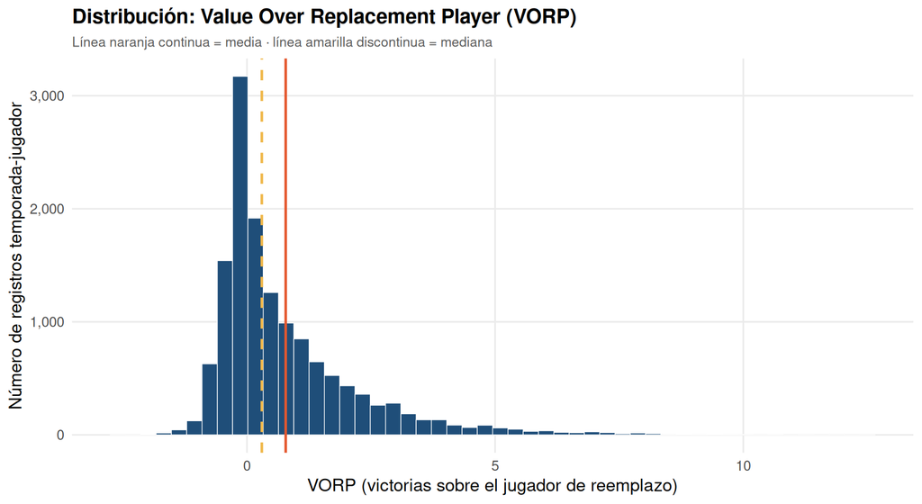

```r
hist_clave("valor_sobre_reemplazo", bins = 50)
```

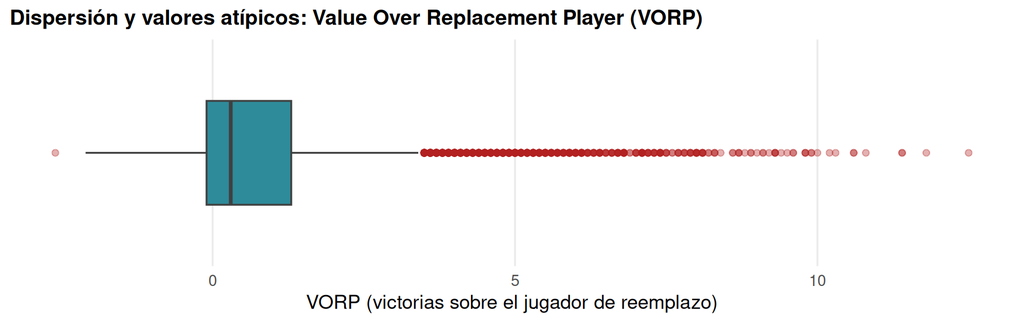

```r
box_clave("valor_sobre_reemplazo")
```

**Interpretación:** La distribución es **fuertemente asimétrica a la derecha** (asimetría = 2.17), y esa forma no es un defecto de los datos: es la estructura económica real de una liga profesional. La mediana es 0.3 y el percentil 75 es 1.3, es decir que **la mitad de las temporadas-jugador del dataset aportan un valor casi indistinguible del de un jugador de reemplazo**. Al mismo tiempo, el percentil 99 llega a 6.4 y el máximo a 12.5: el valor está **concentrado en una minoría diminuta de superestrellas**. 32.0% de los registros tiene VORP negativo — jugadores que, según el modelo, rindieron por debajo de lo que un fichaje de mínimo salarial habría dado.

Para un front office, la lectura es directa: la enorme nube de *outliers* superiores del boxplot no son datos a limpiar, **son precisamente los jugadores por los que se paga el salario máximo**. Nótese además que VORP es una métrica **acumulativa**, no una tasa: un jugador con pocos minutos simplemente acumula un VORP cercano a cero, en lugar de producir el valor extremo y engañoso que daría una métrica por minuto — razón por la cual es más robusta que el PER para comparar jugadores de distinto volumen de juego.

## 8.2 2. Puntos por partido — dimensión: producción

`puntos_pp` es la estadística ofensiva más visible del baloncesto y la que mayor **comunalidad** presenta en el dataset (0.95 sobre 4 componentes principales): es la variable que mejor resume el “cluster de volumen” formado por tiros anotados, tiros intentados y tiros de 2 puntos.

```r
bloque_tablas_clave("puntos_pp")$stats
```

| Media | Mediana | Desviación estándar | Mínimo | Máximo | Asimetría | Valores NA |
| --- | --- | --- | --- | --- | --- | --- |
| 9.405 | 7.9 | 6.098 | 0.3 | 37.1 | 0.952 | 0 |

```r
bloque_tablas_clave("puntos_pp")$cuantiles
```

Cuantiles de la distribución

| P1 | P10 | P25 (Q1) | Mediana (Q2) | P75 (Q3) | P90 | P99 |
| --- | --- | --- | --- | --- | --- | --- |
| 1.3 | 2.8 | 4.5 | 7.9 | 13 | 18.3 | 27.1 |

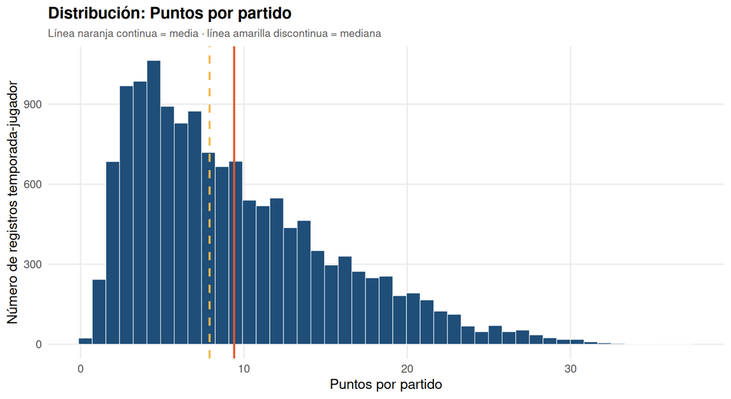

```r
hist_clave("puntos_pp", bins = 45)
```

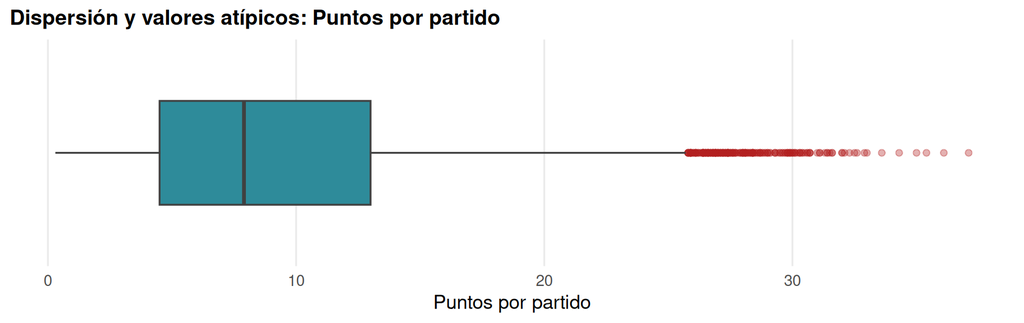

```r
box_clave("puntos_pp")
```

**Interpretación:** Con una media de 9.4 puntos y una mediana de 7.9, la distribución mantiene una **asimetría moderada a la derecha** (asimetría = 0.95) incluso después de filtrar a los jugadores marginales: la mayoría de los profesionales de la NBA anotan en un rango estrecho de roles secundarios, y una minoría de anotadores de élite se aleja mucho hacia arriba (P99 = 27.1 puntos, máximo 37.1). `puntos_pp` mide **volumen, no eficiencia ni valor**: un jugador puede promediar 20 puntos con un porcentaje de tiro pobre y estar restando valor neto a su equipo; por eso esta variable debe interpretarse siempre junto con `porc_tiro_verdadero` (eficiencia, sección 4) y `porc_uso_jugador` (cuántas jugadas consumió para conseguirlos, sección 5), que es exactamente la razón por la que las tres aparecen como dimensiones separadas en este panel.

## 8.3 3. Minutos totales en la temporada — dimensión: oportunidad

`minutos_totales` es la variable de **oportunidad**: cuánto tiempo real de juego recibió el jugador. Es el **predictor #1 de los Win Shares** (importancia 0.345) y el control obligatorio de cualquier métrica acumulativa. También es la variable sobre la que se aplicó el filtro de depuración (`>= 100` minutos).

```r
bloque_tablas_clave("minutos_totales")$stats
```

| Media | Mediana | Desviación estándar | Mínimo | Máximo | Asimetría | Valores NA |
| --- | --- | --- | --- | --- | --- | --- |
| 1442.599 | 1407 | 867.389 | 100 | 3533 | 0.185 | 0 |

```r
bloque_tablas_clave("minutos_totales")$cuantiles
```

Cuantiles de la distribución

| P1 | P10 | P25 (Q1) | Mediana (Q2) | P75 (Q3) | P90 | P99 |
| --- | --- | --- | --- | --- | --- | --- |
| 114 | 279 | 683 | 1407 | 2139.75 | 2668 | 3161.23 |

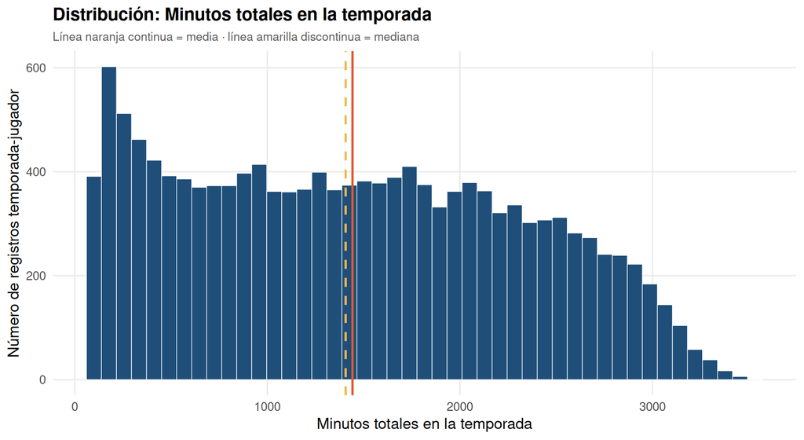

```r
hist_clave("minutos_totales", bins = 45)
```

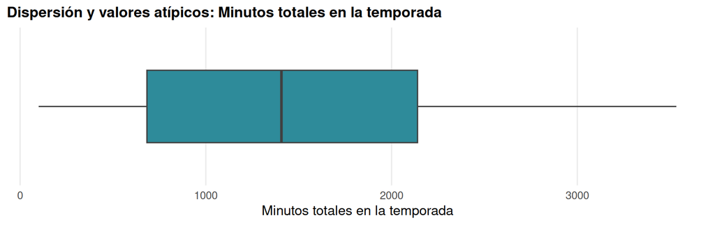

```r
box_clave("minutos_totales")
```

**Interpretación:** Es, con diferencia, la variable **más simétrica** de las 10 claves (asimetría = 0.18, media 1,443 y mediana 1,407 prácticamente idénticas) y **no presenta apenas valores atípicos**: el boxplot es notablemente limpio. La explicación es estructural: los minutos están **acotados por arriba** por la propia estructura de la competición (82 partidos × 48 minutos) y, por abajo, por el filtro de 100 minutos, de modo que la variable se reparte de forma bastante uniforme entre el suplente de rotación corta y el titular de minutos altos.

Su utilidad en el análisis es doble. Primero, es el **mejor proxy de la confianza del cuerpo técnico**: los minutos son un recurso escaso que el entrenador asigna, y esa asignación es en sí misma una evaluación profesional del jugador. Segundo, y más importante metodológicamente, es la variable de **confusión** que explica buena parte de las correlaciones fuertes del dataset: casi todas las estadísticas “por partido” dependen mecánicamente de cuánto tiempo tiene el jugador para producirlas. Comparar producción sin controlar por minutos es el error más frecuente en analítica deportiva amateur — y la razón por la que este panel prefiere métricas normalizadas por posesión (TRB%, AST%) en las secciones 6 y 7.

## 8.4 4. Porcentaje de tiro verdadero (TS%) — dimensión: eficiencia

`porc_tiro_verdadero` (*True Shooting %*) es la medida moderna de **eficiencia anotadora**: combina tiros de 2, triples y tiros libres en un solo porcentaje, ponderando cada uno por los puntos que realmente produce. Es la variable **#1 para explicar el VORP** y **#2 para los Win Shares**, y —crucialmente— aporta información **independiente del volumen**: su correlación con el porcentaje de uso es de apenas r = 0.11.

```r
bloque_tablas_clave("porc_tiro_verdadero")$stats
```

| Media | Mediana | Desviación estándar | Mínimo | Máximo | Asimetría | Valores NA |
| --- | --- | --- | --- | --- | --- | --- |
| 0.525 | 0.528 | 0.059 | 0.184 | 0.746 | -0.437 | 0 |

```r
bloque_tablas_clave("porc_tiro_verdadero")$cuantiles
```

Cuantiles de la distribución

| P1 | P10 | P25 (Q1) | Mediana (Q2) | P75 (Q3) | P90 | P99 |
| --- | --- | --- | --- | --- | --- | --- |
| 0.36 | 0.453 | 0.492 | 0.528 | 0.562 | 0.594 | 0.662 |

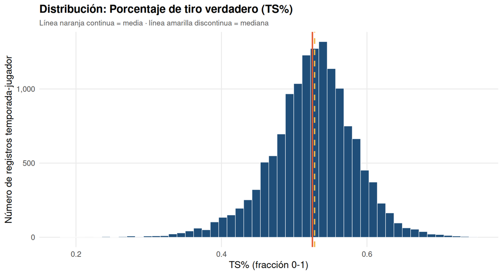

```r
hist_clave("porc_tiro_verdadero", bins = 50)
```

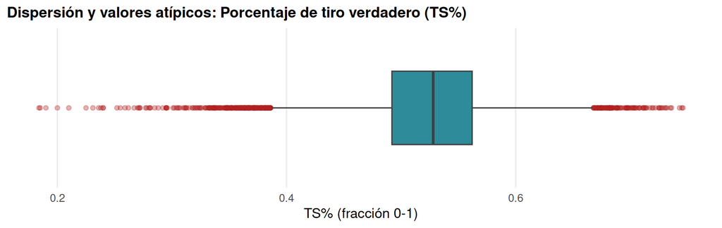

```r
box_clave("porc_tiro_verdadero")
```

**Interpretación:** Es una distribución **unimodal y compacta**, con media 0.525 y mediana 0.528 casi coincidentes, pero con una **asimetría moderada hacia la izquierda** (asimetría = -0.44) — la única cola apreciable de las variables de eficiencia del panel. Esa cola izquierda tiene una lectura deportiva concreta: los *outliers* inferiores del boxplot son temporadas de **eficiencia anómalamente mala**, y la liga tolera muy pocas de ellas (el P1 está en 0.36), mientras que por arriba el techo es mucho más rígido —el P99 es 0.662 y el máximo 0.746. En otras palabras: **se puede ser mucho peor que el promedio tirando, pero no mucho mejor**.

Esta rigidez del techo es justamente lo que hace valiosa a la variable. La desviación estándar es de solo 0.059, así que una diferencia que parece trivial —cuatro puntos de TS%— equivale a más de media desviación estándar y separa a un anotador de élite de uno mediocre. Nótese también el efecto de la depuración: en el archivo original esta columna llegaba a valores superiores a 1.0 (matemáticamente imposibles como “porcentaje”) porque jugadores con dos o tres intentos en toda la temporada producían cocientes absurdos; aquí el máximo es 0.746, un valor plausible.

## 8.5 5. Porcentaje de uso (USG%) — dimensión: rol

`porc_uso_jugador` (*Usage %*) estima qué porcentaje de las jugadas de su equipo **terminó el jugador** (con un tiro, una falta recibida o una pérdida) mientras estaba en cancha. Es la medida canónica del **protagonismo ofensivo** y forma un cluster propio en la matriz de correlación: r = 0.73 con los puntos por partido, suficientemente alto para confirmar que mide algo relacionado, pero lejos de la redundancia.

```r
bloque_tablas_clave("porc_uso_jugador")$stats
```

| Media | Mediana | Desviación estándar | Mínimo | Máximo | Asimetría | Valores NA |
| --- | --- | --- | --- | --- | --- | --- |
| 18.905 | 18.6 | 4.974 | 3.7 | 41.7 | 0.378 | 0 |

```r
bloque_tablas_clave("porc_uso_jugador")$cuantiles
```

Cuantiles de la distribución

| P1 | P10 | P25 (Q1) | Mediana (Q2) | P75 (Q3) | P90 | P99 |
| --- | --- | --- | --- | --- | --- | --- |
| 8.6 | 12.8 | 15.4 | 18.6 | 22.1 | 25.5 | 32.023 |

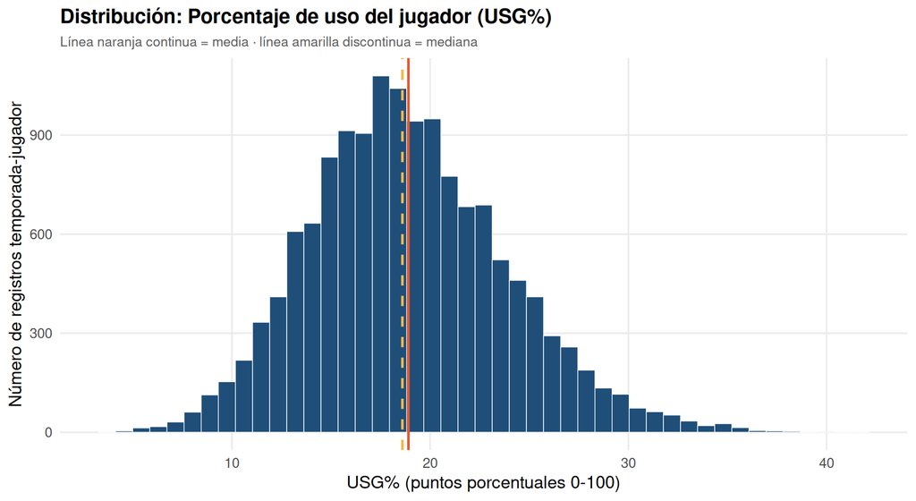

```r
hist_clave("porc_uso_jugador", bins = 45)
```

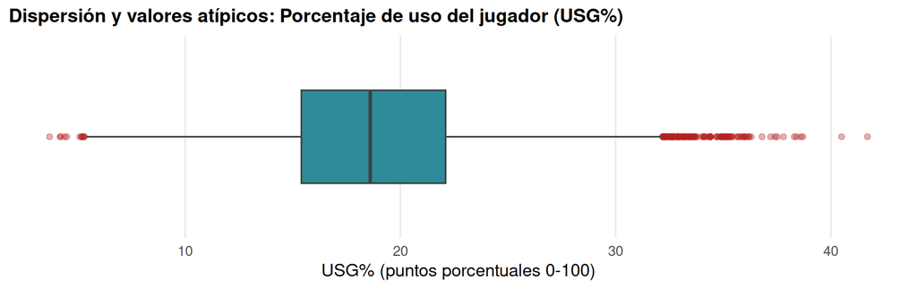

```r
box_clave("porc_uso_jugador")
```

**Interpretación:** La distribución es **notablemente simétrica y compacta** (media 18.9, mediana 18.6, asimetría 0.38), y eso tiene una causa aritmética elegante: **los porcentajes de uso de los cinco jugadores en cancha deben sumar aproximadamente 100**, de modo que el promedio de la liga está anclado cerca del 20% por construcción. Es, de hecho, una variable con un **límite superior real de comportamiento**: el máximo observado es 41.7%, porque ningún equipo puede canalizar mucho más de dos quintas partes de su ofensiva por un solo jugador sin volverse trivialmente predecible.

El valor analítico de esta variable está en **combinarla con la eficiencia** (sección 4). Ese cruce es la pregunta central de la evaluación ofensiva moderna: un USG% alto con un TS% alto identifica a un **primer espada legítimo** (puede sostener una ofensiva sin perder eficiencia); un USG% alto con TS% bajo identifica a un jugador que **consume posesiones sin convertirlas** —el perfil que más daño silencioso hace a un equipo—; y un USG% bajo con TS% alto describe al **especialista de rol** que rentabiliza cada oportunidad que recibe. Que la correlación entre ambas sea de apenas r = 0.11 demuestra que los cuatro cuadrantes están genuinamente poblados: **el volumen no compra eficiencia, ni la penaliza de forma automática**.

## 8.6 6. Porcentaje de rebotes totales capturados (TRB%) — dimensión: interior

`porc_rebotes_tot_disp` (*Total Rebound %*) estima qué porcentaje de **todos los rebotes disponibles** capturó el jugador mientras estaba en cancha. Tiene la **carga máxima del segundo componente principal** (0.89) y representa a los tres indicadores de rebote normalizados (`porc_rebotes_of_disp`, `porc_rebotes_def_disp`, `porc_rebotes_tot_disp`), con los que correlaciona por encima de r = 0.88. Se prefiere a `rebotes_totales_pp` porque **no depende de los minutos jugados**.

```r
bloque_tablas_clave("porc_rebotes_tot_disp")$stats
```

| Media | Mediana | Desviación estándar | Mínimo | Máximo | Asimetría | Valores NA |
| --- | --- | --- | --- | --- | --- | --- |
| 10.079 | 9.3 | 4.481 | 1 | 29.7 | 0.566 | 0 |

```r
bloque_tablas_clave("porc_rebotes_tot_disp")$cuantiles
```

Cuantiles de la distribución

| P1 | P10 | P25 (Q1) | Mediana (Q2) | P75 (Q3) | P90 | P99 |
| --- | --- | --- | --- | --- | --- | --- |
| 3.3 | 4.9 | 6.3 | 9.3 | 13.4 | 16.4 | 21.2 |

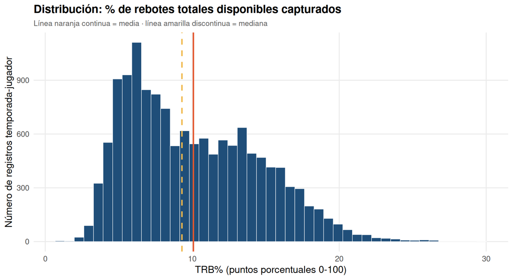

```r
hist_clave("porc_rebotes_tot_disp", bins = 45)
```

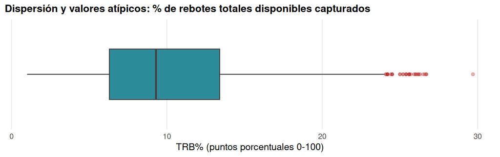

```r
box_clave("porc_rebotes_tot_disp")
```

**Interpretación:** La distribución global es asimétrica a la derecha (asimetría = 0.57), con mediana 9.3% y un máximo de 29.7% — es decir, el mejor reboteador histórico capturó casi un tercio de todos los rebotes disponibles mientras estaba en cancha, algo notable considerando que compite contra nueve jugadores más. La ventaja de usar la versión normalizada en lugar de los rebotes por partido es directamente comprobable en los datos: ambas solo correlacionan a r = 0.68, y la diferencia entre ellas **son los minutos**. Un suplente que captura el 15% de los rebotes disponibles es mejor reboteador que un titular que captura el 10%, aunque el segundo promedie más rebotes por partido; la métrica “por partido” invertiría ese orden y llevaría a una decisión de fichaje equivocada.

## 8.7 7. Porcentaje de asistencias del equipo (AST%) — dimensión: creación

`porc_asistencias_equipo` (*Assist %*) estima qué porcentaje de las canastas de sus compañeros **asistió el jugador** mientras estaba en cancha. Forma un cluster propio en la matriz de correlación y tiene una carga de −0.64 en el segundo componente principal: es el **contrapeso exacto del rebote** en el eje interior-exterior.

```r
bloque_tablas_clave("porc_asistencias_equipo")$stats
```

| Media | Mediana | Desviación estándar | Mínimo | Máximo | Asimetría | Valores NA |
| --- | --- | --- | --- | --- | --- | --- |
| 13.547 | 10.7 | 9.16 | 0 | 57.5 | 1.239 | 0 |

```r
bloque_tablas_clave("porc_asistencias_equipo")$cuantiles
```

Cuantiles de la distribución

| P1 | P10 | P25 (Q1) | Mediana (Q2) | P75 (Q3) | P90 | P99 |
| --- | --- | --- | --- | --- | --- | --- |
| 1.8 | 4.6 | 6.9 | 10.7 | 18.1 | 27.3 | 41.6 |

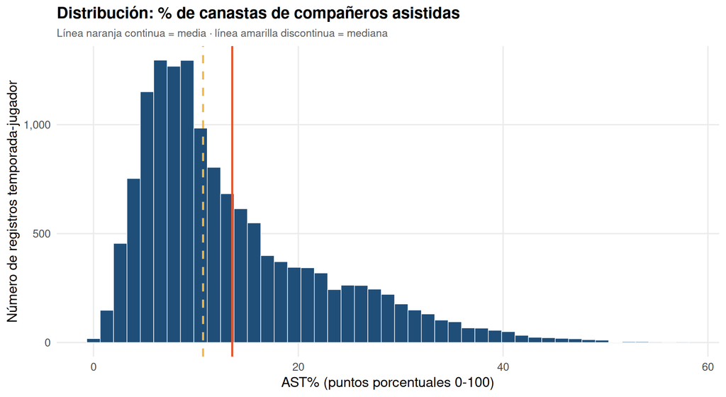

```r
hist_clave("porc_asistencias_equipo", bins = 45)
```

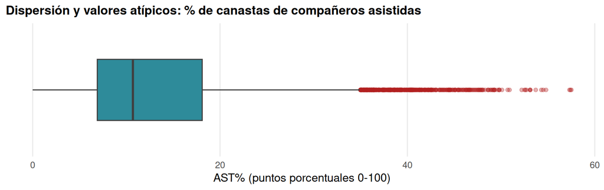

```r
box_clave("porc_asistencias_equipo")
```

**Interpretación:** Es la variable clave con la **asimetría positiva más marcada** después del VORP (asimetría = 1.24): media 13.5% frente a una mediana de 10.7%, con una cola larga que llega hasta 57.5%. La forma refleja un hecho táctico del baloncesto: **la creación de juego es una función concentrada**. La mayoría de los jugadores en cancha no manejan el balón, y un equipo canaliza la organización de su ataque por uno o dos jugadores; el histograma es, en la práctica, la huella estadística de esa división del trabajo. Al igual que con el rebote, se prefiere AST% a `asistencias_pp` porque la versión normalizada no penaliza al creador de juego que sale del banquillo.

## 8.8 8. Proporción de intentos que son de triple — dimensión: estilo y época

`porc_intentos_triple` mide qué fracción de los tiros de campo que intentó el jugador fueron **triples**. Representa a todo el cluster del triple y es la variable **más ligada al paso del tiempo** de todo el dataset (r = 0.5 con `temporada`). Se prefiere a `porc_triple` porque **no sufre su problema de valores faltantes** (`porc_triple` tiene 1,557 `NA`; esta variable, ninguno).

```r
bloque_tablas_clave("porc_intentos_triple")$stats
```

| Media | Mediana | Desviación estándar | Mínimo | Máximo | Asimetría | Valores NA |
| --- | --- | --- | --- | --- | --- | --- |
| 0.19 | 0.113 | 0.201 | 0 | 1 | 0.874 | 0 |

```r
bloque_tablas_clave("porc_intentos_triple")$cuantiles
```

Cuantiles de la distribución

| P1 | P10 | P25 (Q1) | Mediana (Q2) | P75 (Q3) | P90 | P99 |
| --- | --- | --- | --- | --- | --- | --- |
| 0 | 0 | 0.01 | 0.113 | 0.339 | 0.488 | 0.728 |

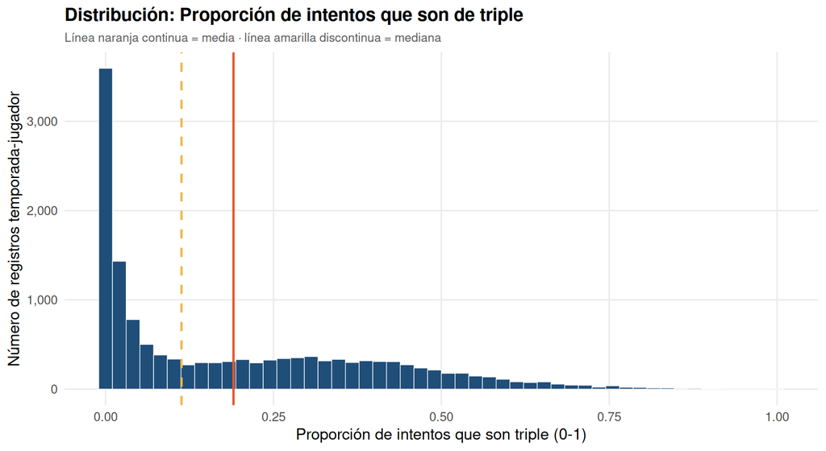

```r
hist_clave("porc_intentos_triple", bins = 50)
```

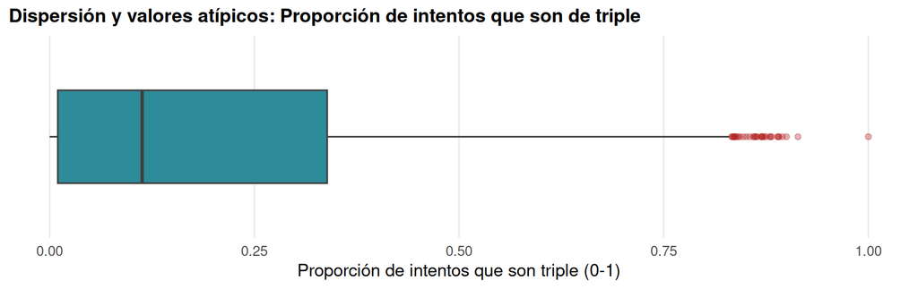

```r
box_clave("porc_intentos_triple")
```

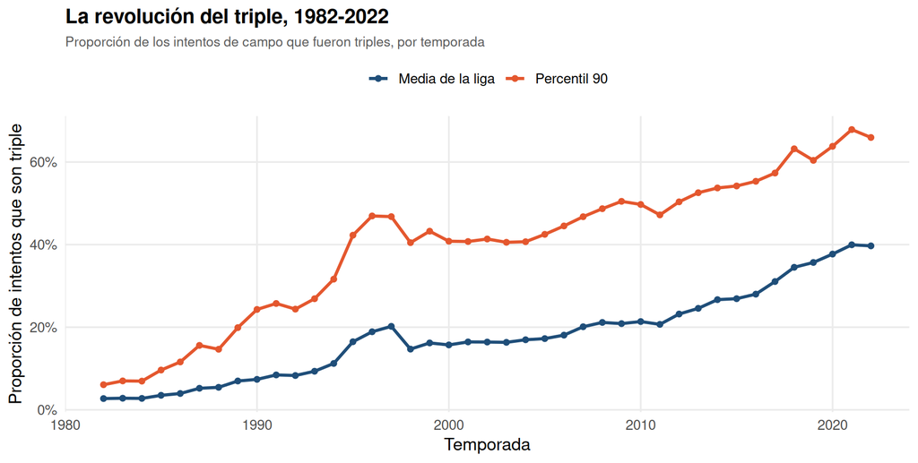

```r
df %>%
  group_by(temporada) %>%
  summarise(
    media = mean(porc_intentos_triple, na.rm = TRUE),
    p90 = quantile(porc_intentos_triple, 0.90, na.rm = TRUE),
    .groups = "drop"
  ) %>%
  pivot_longer(c(media, p90), names_to = "serie", values_to = "valor") %>%
  mutate(serie = recode(serie, media = "Media de la liga", p90 = "Percentil 90")) %>%
  ggplot(aes(x = temporada, y = valor, color = serie)) +
  geom_line(linewidth = 1.1) +
  geom_point(size = 1.6) +
  scale_color_manual(values = c("Media de la liga" = col_hist_clave, "Percentil 90" = "#E4572E")) +
  scale_y_continuous(labels = percent_format(accuracy = 1)) +
  labs(
    title = "La revolución del triple, 1982-2022",
    subtitle = "Proporción de los intentos de campo que fueron triples, por temporada",
    x = "Temporada", y = "Proporción de intentos que son triple", color = NULL
  ) +
  theme_minimal(base_size = 13) +
  theme(
    plot.title = element_text(face = "bold", size = 15),
    plot.subtitle = element_text(size = 10, color = "grey35"),
    legend.position = "top",
    panel.grid.minor = element_blank()
  )
```

**Interpretación:** El histograma de esta variable es el **más peculiar del dataset**: tiene una gran masa concentrada cerca de cero (jugadores que casi nunca lanzan de tres), 11.1% de registros exactamente en 0, y una distribución muy extendida hacia la derecha que llega hasta el 100% (jugadores cuyos tiros fueron **exclusivamente** triples). La mediana (0.113) queda muy por debajo de la media (0.19), señal clara de la cola derecha.

Pero el hallazgo importante de esta variable **no es su forma univariada, sino su dependencia temporal**, que el gráfico de evolución hace evidente: la proporción de triples pasó de ser una anécdota en los años ochenta a una fracción central del ataque en la década de 2020. Esto tiene una consecuencia metodológica de primer orden para todo el documento: **la distribución agregada que muestra el histograma es un artefacto de mezclar 41 temporadas con reglas de juego efectivamente distintas**. No describe a “un jugador de la NBA”, sino a la superposición de varias épocas. Cualquier modelo que use esta variable (o las de triple que representa) debería incluir `temporada` como control, o segmentar el análisis por era; comparar directamente el porcentaje de intentos de triple de un alero de 1985 con uno de 2021 no mide talento individual, mide el **cambio estratégico de la liga**.

## 8.9 9. Box Plus/Minus defensivo (DBPM) — dimensión: defensa

`masmenos_defensivo` estima el impacto **defensivo** del jugador en puntos por cada 100 posesiones, por encima o por debajo del jugador promedio de la liga. Ocupa un **cluster aislado** en la matriz de correlación: correlaciona solo ρ = 0.40 con el VORP, lo que confirma que la defensa es una **dimensión propia** del rendimiento y no un subproducto del ataque.

```r
bloque_tablas_clave("masmenos_defensivo")$stats
```

| Media | Mediana | Desviación estándar | Mínimo | Máximo | Asimetría | Valores NA |
| --- | --- | --- | --- | --- | --- | --- |
| -0.048 | -0.1 | 1.214 | -6.7 | 5.5 | 0.283 | 0 |

```r
bloque_tablas_clave("masmenos_defensivo")$cuantiles
```

Cuantiles de la distribución

| P1 | P10 | P25 (Q1) | Mediana (Q2) | P75 (Q3) | P90 | P99 |
| --- | --- | --- | --- | --- | --- | --- |
| -2.7 | -1.5 | -0.9 | -0.1 | 0.7 | 1.5 | 3.1 |

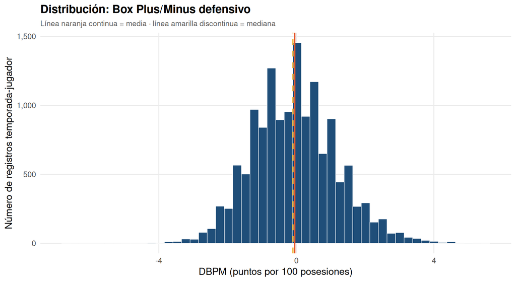

```r
hist_clave("masmenos_defensivo", bins = 50)
```

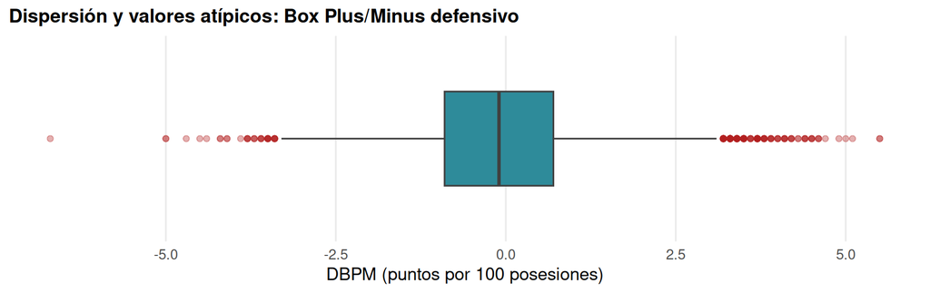

```r
box_clave("masmenos_defensivo")
```

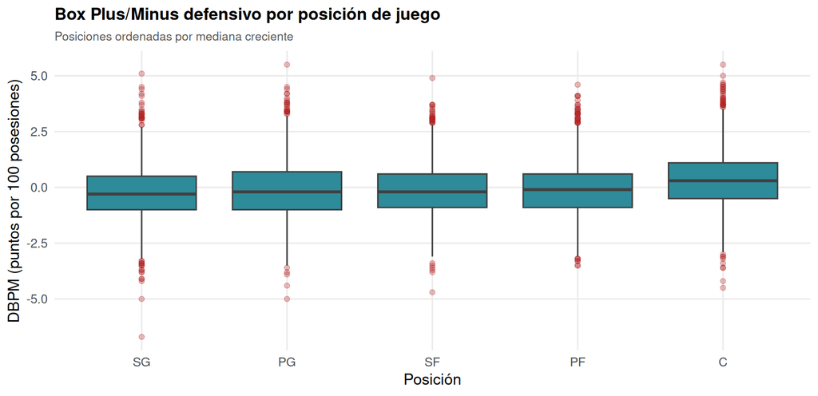

```r
box_por_posicion("masmenos_defensivo")
```

**Interpretación:** La distribución está **centrada en cero casi exactamente** (media -0.048, mediana -0.1) y es **aproximadamente simétrica** (asimetría = 0.28), lo cual es esperable por diseño: la métrica se define como desviación respecto al jugador promedio, así que el promedio debe ser cero. Lo informativo aquí es la **escala**: la desviación estándar es de solo 1.21 puntos por 100 posesiones, y el rango completo va de -6.7 a 5.5. Compárese con el Box Plus/Minus **ofensivo**, cuya desviación estándar es 2.66 — más del doble.

El boxplot por posición añade un matiz coherente con esa escala comprimida: los pívots son la única posición con mediana **positiva** (0.3, frente a -0.3 en los escoltas), lo que refleja que la métrica premia las acciones defensivas que la hoja de estadísticas **sí** registra —tapones y rebotes defensivos—, ambas concentradas en el juego interior. Pero las diferencias entre posiciones son de apenas medio punto por 100 posesiones: mucho menores que las que la misma métrica encuentra entre jugadores individuales.

Esa diferencia de escalas es el hallazgo central, y tiene dos lecturas posibles que conviene no confundir. La primera es sustantiva: **la variación entre jugadores es mucho mayor en ataque que en defensa**, porque el ataque depende de habilidades individuales (tiro, manejo) mientras que la defensa es un esfuerzo coordinado de cinco jugadores, lo que comprime las diferencias individuales. La segunda es una limitación del dato: el DBPM se estima **a partir de la hoja de estadísticas tradicional**, que solo registra robos, tapones y rebotes defensivos —eventos raros que capturan una fracción pequeña de lo que realmente hace un buen defensor (rotaciones, cierres de línea de pase, contestar un tiro sin bloquearlo). Por eso, aunque es la mejor variable defensiva disponible en este dataset y su inclusión es indispensable, **debe usarse con más cautela que sus equivalentes ofensivos**: su rango estrecho refleja tanto la realidad del juego como los límites de la medición.

## 8.10 10. Porcentaje de victorias del equipo — dimensión: contexto

`porc_victorias_equipo` es un **atributo del equipo**, no del jugador: el mismo valor se repite en todas las filas de jugadores de una misma franquicia y temporada. Tiene la **carga máxima del tercer componente principal** (0.73) y representa a `margen_victoria` y `margen_victoria_ajust`, con los que correlaciona por encima de r = 0.96.

```r
bloque_tablas_clave("porc_victorias_equipo")$stats
```

| Media | Mediana | Desviación estándar | Mínimo | Máximo | Asimetría | Valores NA |
| --- | --- | --- | --- | --- | --- | --- |
| 0.499 | 0.512 | 0.155 | 0.106 | 0.89 | -0.18 | 0 |

```r
bloque_tablas_clave("porc_victorias_equipo")$cuantiles
```

Cuantiles de la distribución

| P1 | P10 | P25 (Q1) | Mediana (Q2) | P75 (Q3) | P90 | P99 |
| --- | --- | --- | --- | --- | --- | --- |
| 0.171 | 0.28 | 0.378 | 0.512 | 0.611 | 0.695 | 0.805 |

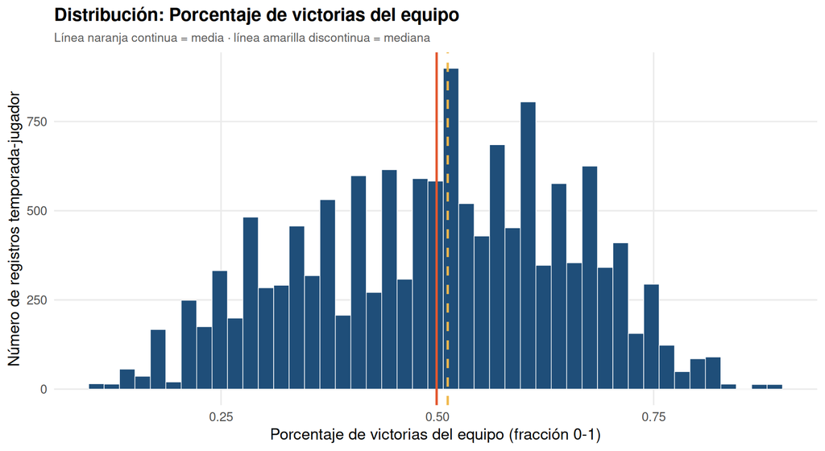

```r
hist_clave("porc_victorias_equipo", bins = 45)
```

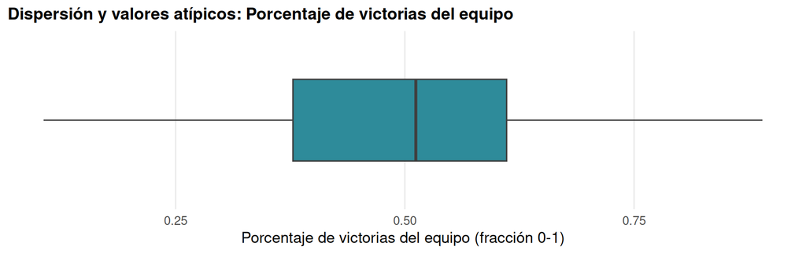

```r
box_clave("porc_victorias_equipo")
```

**Interpretación:** La distribución está **centrada en 0.5 por construcción de la competición** (media 0.499, mediana 0.512): en una liga cerrada, cada victoria de un equipo es la derrota de otro, de modo que el porcentaje medio de victorias **tiene que** ser 0.5. Que la media empírica coincida con ese valor teórico es una **verificación de consistencia del dataset**, no un hallazgo. Es además la variable clave más simétrica junto a los minutos (asimetría = -0.18), y su rango (0.106 a 0.89) describe la distancia real entre la peor y la mejor temporada de franquicia del periodo.

Su papel en el panel es servir de **contexto**, y su principal utilidad es metodológica: advierte contra un error de inferencia muy común. Como el valor está repetido para todos los jugadores de un mismo equipo, **una correlación alta entre esta variable y una estadística individual no significa que el jugador haga ganar a su equipo**; puede significar lo contrario (que jugar en un buen equipo infla las estadísticas del jugador), o simplemente reflejar que los buenos equipos acumulan buenos jugadores. Es una variable **de nivel agregado mezclada en una tabla de nivel individual**, y tratarla como si fuera un atributo del jugador es un caso de libro de la *falacia ecológica*. Su correlación con el margen de victoria (r = 0.968) se analiza en detalle en la sección de matriz de correlación, donde se muestra que es el hallazgo empírico más robusto del dataset.

## 8.11 Resto de variables numéricas

Las 40 variables numéricas que **no** forman parte del panel clave se analizan a continuación de forma sistemática y compacta: para cada una se muestra su descripción (tomada del diccionario de datos), la tabla de estadísticos, histograma y boxplot lado a lado, y una interpretación generada a partir de su asimetría y su proporción de valores `NA`.

Estas variables no son irrelevantes: muchas son componentes de las claves (por ejemplo `rebotes_of_pp` y `rebotes_def_pp` respecto a TRB%) o versiones sin normalizar de ellas. Se presentan con **menor protagonismo visual** justamente porque la sección de correlación demuestra que su información está en gran medida **contenida en las 10 variables clave**.

```r
interpretar_numerica <- function(v) {
  x <- df[[v]]
  desc <- diccionario$Descripcion_academica[diccionario$Variable == v]
  n_na <- sum(is.na(x))
  sk <- suppressWarnings(e1071::skewness(x, na.rm = TRUE, type = 2))

  forma <- case_when(
    is.na(sk) ~ "no pudo estimarse por datos insuficientes",
    abs(sk) < 0.5 ~ "una distribución aproximadamente simétrica",
    sk >= 0.5 & sk < 1 ~ "una asimetría moderada hacia la derecha (cola de valores altos)",
    sk <= -0.5 & sk > -1 ~ "una asimetría moderada hacia la izquierda (cola de valores bajos)",
    sk >= 1 ~ "una asimetría fuerte hacia la derecha: la mayoría de registros se concentra en valores bajos y una minoría se aleja mucho hacia arriba",
    sk <= -1 ~ "una asimetría fuerte hacia la izquierda: la mayoría de registros se concentra en valores altos y una minoría se aleja mucho hacia abajo",
    TRUE ~ "una forma que no encaja en las categorías estándar de asimetría"
  )

  nota_na <- if (n_na > 0) {
    paste0(
      " Presenta ", comma(n_na), " valores NA (",
      percent(n_na / nrow(df), accuracy = 0.1),
      "), consistentes con el patrón estructural de porcentajes 0/0 ",
      "documentado en la sección de calidad de datos."
    )
  } else {
    " No presenta valores NA."
  }

  # Variable clave a la que esta variable queda representada, si aplica
  representada_por <- c(
    rebotes_of_pp = "porc_rebotes_tot_disp", rebotes_def_pp = "porc_rebotes_tot_disp",
    rebotes_totales_pp = "porc_rebotes_tot_disp",
    porc_rebotes_of_disp = "porc_rebotes_tot_disp",
    porc_rebotes_def_disp = "porc_rebotes_tot_disp",
    asistencias_pp = "porc_asistencias_equipo",
    tiros_anotados_pp = "puntos_pp", tiros_intentados_pp = "puntos_pp",
    dobles_anotados_pp = "puntos_pp", dobles_intentados_pp = "puntos_pp",
    porc_tiro_campo = "porc_tiro_verdadero", porc_doble = "porc_tiro_verdadero",
    porc_tiro_efectivo = "porc_tiro_verdadero",
    triples_anotados_pp = "porc_intentos_triple",
    triples_intentados_pp = "porc_intentos_triple",
    porc_triple = "porc_intentos_triple",
    victorias_total = "valor_sobre_reemplazo",
    victorias_ofensiva = "valor_sobre_reemplazo",
    victorias_defensa = "valor_sobre_reemplazo",
    victorias_por_48min = "valor_sobre_reemplazo",
    masmenos_total = "valor_sobre_reemplazo",
    masmenos_ofensivo = "valor_sobre_reemplazo",
    indice_eficiencia = "valor_sobre_reemplazo",
    margen_victoria = "porc_victorias_equipo",
    margen_victoria_ajust = "porc_victorias_equipo",
    minutos_pp = "minutos_totales"
  )

  nota_clave <- if (v %in% names(representada_por)) {
    rep_v <- representada_por[[v]]
    paste0(
      " En el panel de variables clave queda representada por `",
      rep_v, "` (r = ",
      round(cor(df[[v]], df[[rep_v]], use = "pairwise.complete.obs"), 2),
      ")."
    )
  } else {
    ""
  }

  paste0(
    desc, " Estadísticamente presenta ", forma,
    " (asimetría = ", round(sk, 2), ").", nota_na, nota_clave
  )
}
```

```r
for (v in vars_restantes) {

  etiqueta <- etiquetas_num[[v]]

  cat("\n\n### ", etiqueta, " (`", v, "`)\n\n", sep = "")

  x <- df[[v]]

  print(
    tabla_stats(x) %>%
      kable(digits = 3, col.names = nombres_stats) %>%
      kable_styling(bootstrap_options = c("striped", "condensed"), full_width = FALSE)
  )

  p_hist <- ggplot(df, aes(x = .data[[v]]))

  # "edad" toma pocos valores enteros (18-43): con bins = 30 el ancho de
  # barra queda por debajo de 1 año y deja huecos vacíos entre edades.
  if (v == "edad") {
    p_hist <- p_hist +
      geom_histogram(binwidth = 1, fill = col_hist, color = "white", linewidth = 0.2, na.rm = TRUE)
  } else {
    p_hist <- p_hist +
      geom_histogram(bins = 30, fill = col_hist, color = "white", linewidth = 0.2, na.rm = TRUE)
  }

  p_hist <- p_hist +
    labs(title = paste("Distribución:", etiqueta), x = etiqueta, y = "Frecuencia") +
    theme_minimal(base_size = 9) +
    theme(plot.title = element_text(size = 10))

  p_box <- ggplot(df, aes(y = .data[[v]])) +
    geom_boxplot(fill = col_box, outlier.color = col_outlier, outlier.alpha = 0.3, na.rm = TRUE) +
    labs(title = paste("Dispersión:", etiqueta), y = etiqueta, x = NULL) +
    theme_minimal(base_size = 9) +
    theme(
      plot.title = element_text(size = 10),
      axis.text.x = element_blank(),
      panel.grid.major.x = element_blank()
    )

  print(p_hist + p_box + plot_layout(widths = c(2.2, 1)))

  cat("\n\n**Interpretación:** ", interpretar_numerica(v), "\n\n", sep = "")
}
```

### 8.11.1 Edad del jugador (`edad`)

| Media | Mediana | Desviación estándar | Mínimo | Máximo | Asimetría | Valores NA |
| --- | --- | --- | --- | --- | --- | --- |
| 26.686 | 26 | 4.142 | 18 | 43 | 0.558 | 0 |

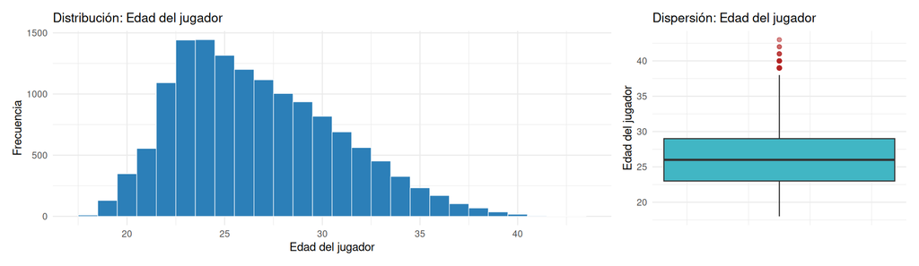

**Interpretación:** Edad del jugador durante esa temporada. Estadísticamente presenta una asimetría moderada hacia la derecha (cola de valores altos) (asimetría = 0.56). No presenta valores NA.

### 8.11.2 Partidos jugados (`partidos_jugados`)

| Media | Mediana | Desviación estándar | Mínimo | Máximo | Asimetría | Valores NA |
| --- | --- | --- | --- | --- | --- | --- |
| 59.791 | 66 | 20.613 | 3 | 82 | -0.815 | 0 |

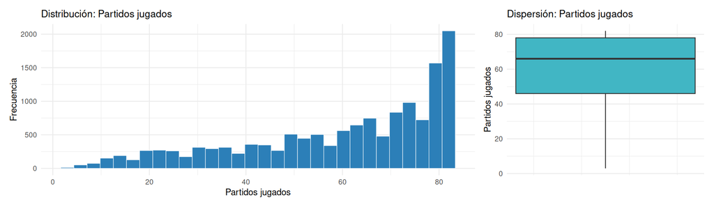

**Interpretación:** Partidos jugados en la temporada. Estadísticamente presenta una asimetría moderada hacia la izquierda (cola de valores bajos) (asimetría = -0.81). No presenta valores NA.

### 8.11.3 Partidos como titular (`partidos_titular`)

| Media | Mediana | Desviación estándar | Mínimo | Máximo | Asimetría | Valores NA |
| --- | --- | --- | --- | --- | --- | --- |
| 30.408 | 18 | 30.112 | 0 | 82 | 0.524 | 0 |

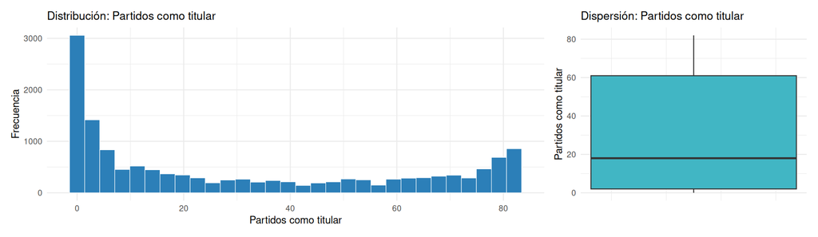

**Interpretación:** Partidos jugados como titular. Estadísticamente presenta una asimetría moderada hacia la derecha (cola de valores altos) (asimetría = 0.52). No presenta valores NA.

### 8.11.4 Minutos por partido (`minutos_pp`)

| Media | Mediana | Desviación estándar | Mínimo | Máximo | Asimetría | Valores NA |
| --- | --- | --- | --- | --- | --- | --- |
| 22.412 | 22.2 | 9.414 | 3 | 43.7 | 0.032 | 0 |

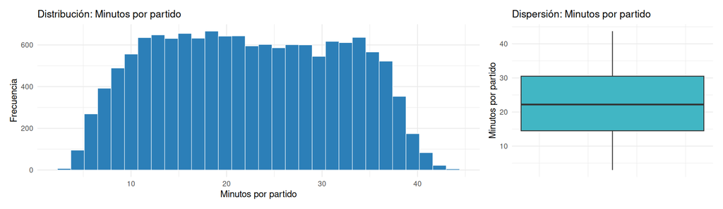

**Interpretación:** Minutos jugados por partido. Estadísticamente presenta una distribución aproximadamente simétrica (asimetría = 0.03). No presenta valores NA. En el panel de variables clave queda representada por `minutos_totales` (r = 0.89).

### 8.11.5 Tiros de campo anotados por partido (`tiros_anotados_pp`)

| Media | Mediana | Desviación estándar | Mínimo | Máximo | Asimetría | Valores NA |
| --- | --- | --- | --- | --- | --- | --- |
| 3.559 | 3 | 2.266 | 0.1 | 13.4 | 0.887 | 0 |

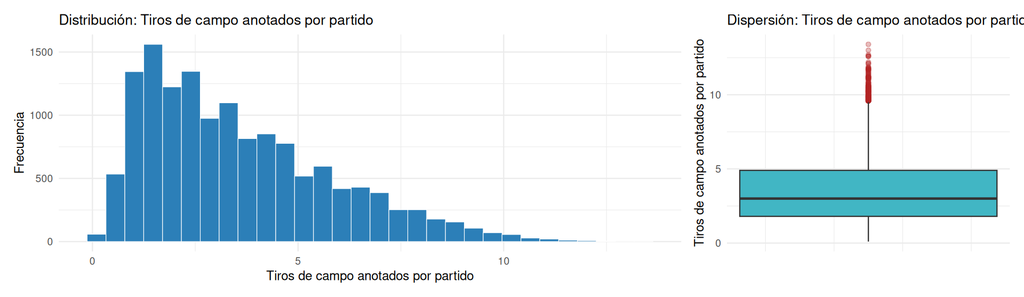

**Interpretación:** Canastas de campo anotadas por partido. Estadísticamente presenta una asimetría moderada hacia la derecha (cola de valores altos) (asimetría = 0.89). No presenta valores NA. En el panel de variables clave queda representada por `puntos_pp` (r = 0.99).

### 8.11.6 Tiros de campo intentados por partido (`tiros_intentados_pp`)

| Media | Mediana | Desviación estándar | Mínimo | Máximo | Asimetría | Valores NA |
| --- | --- | --- | --- | --- | --- | --- |
| 7.737 | 6.7 | 4.688 | 0.4 | 27.8 | 0.823 | 0 |

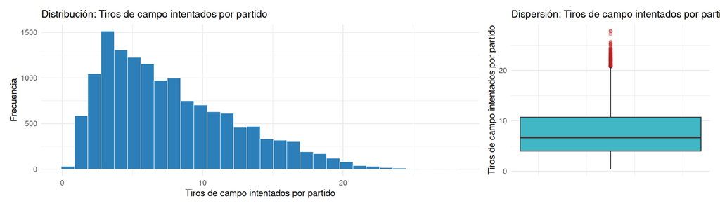

**Interpretación:** Intentos de canasta de campo por partido. Estadísticamente presenta una asimetría moderada hacia la derecha (cola de valores altos) (asimetría = 0.82). No presenta valores NA. En el panel de variables clave queda representada por `puntos_pp` (r = 0.98).

### 8.11.7 Porcentaje de tiro de campo (`porc_tiro_campo`)

| Media | Mediana | Desviación estándar | Mínimo | Máximo | Asimetría | Valores NA |
| --- | --- | --- | --- | --- | --- | --- |
| 0.454 | 0.451 | 0.064 | 0.15 | 0.778 | 0.213 | 0 |

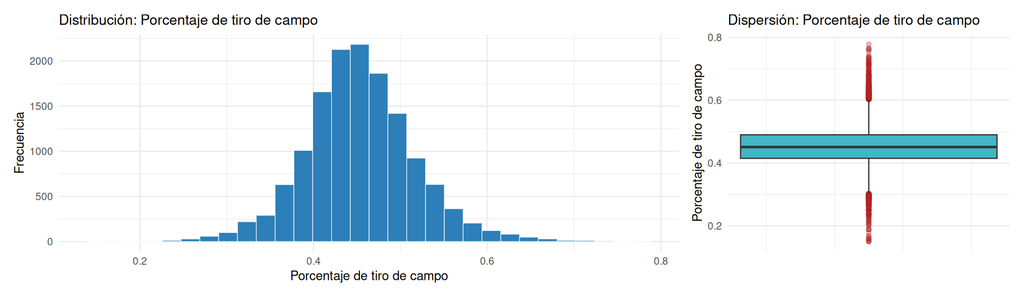

**Interpretación:** Porcentaje de acierto en tiros de campo. Estadísticamente presenta una distribución aproximadamente simétrica (asimetría = 0.21). No presenta valores NA. En el panel de variables clave queda representada por `porc_tiro_verdadero` (r = 0.79).

### 8.11.8 Triples anotados por partido (`triples_anotados_pp`)

| Media | Mediana | Desviación estándar | Mínimo | Máximo | Asimetría | Valores NA |
| --- | --- | --- | --- | --- | --- | --- |
| 0.523 | 0.2 | 0.685 | 0 | 5.3 | 1.566 | 0 |

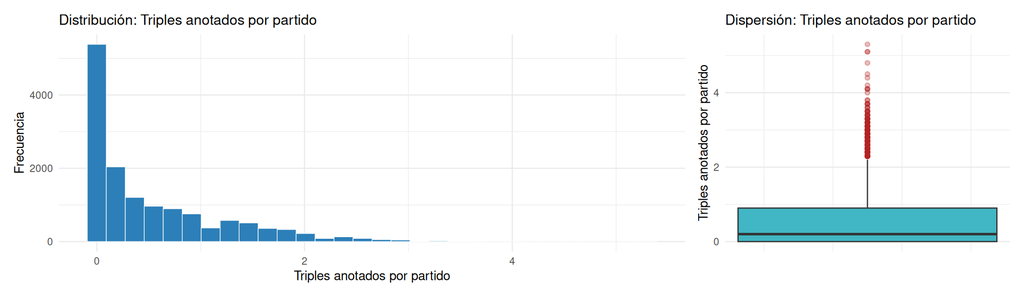

**Interpretación:** Triples anotados por partido. Estadísticamente presenta una asimetría fuerte hacia la derecha: la mayoría de registros se concentra en valores bajos y una minoría se aleja mucho hacia arriba (asimetría = 1.57). No presenta valores NA. En el panel de variables clave queda representada por `porc_intentos_triple` (r = 0.76).